# GLM

Dudot Lucas - Lapaz Eudes - Moinard Benjamin - Nanoux Louis

2023-01-30

```r
library(FactoMineR)
library(factoextra)
library(CASdatasets)
library(tidyverse)
library(MASS)
library(knitr)
library(ggplot2)
library(cowplot)
library(reshape2)
library(dplyr)
library(GGally)
library(corrplot)
library(carData)
library(car)
library(questionr)
library(multcomp)
library(dplyr)
library(leaps)
library(TeachingDemos)
library(factoextra)
library(ROCR)
library(plotROC)
library(caret)
```

# GLM pour la variable coût

## I) Transformation de certaines variables en variables catégorielles

```r
data(freMPL5)
```

Notre variable “ClaimAmount” est une variable quantitative et représente le prix total des accidents survenus au cours de l’année pour chacun des assurés.

Cette variable prend ainsi une valeur nulle lorque la variable “ClaimInd” a la valeur nulle, c’est-à-dire si aucun accident n’est survenu et prend des valeurs positives dans le cas contraire.

```r
summary(freMPL5$ClaimAmount)
```

```
##    Min. 1st Qu.  Median    Mean 3rd Qu.    Max.
## -1842.0     0.0     0.0   204.9     0.0 95151.0
```

Seulement, nos données présentent des cas particuliés et isolés dans laquelle la variable ClaimAmount prend des valeurs négatives. Nous élimineront ces données dans la suite de notre étude de la variable et nous nous intéresserons aux valeurs que celle-ci peut prendre lorsqu’un incident a lieu.

Nous utiliserons également le même découpage réalisé lors de l’étude de la variable fréquence.

```r
#enlever les valeurs négatives
freMPL5 <- subset(freMPL5, freMPL5$ClaimAmount >= 0)

#passer en variables catégorielles
freMPL5$HasKmLimit <- factor(freMPL5$HasKmLimit)
freMPL5$ClaimInd <- factor(freMPL5$ClaimInd)

#segmentation des tranches d'âge
freMPL5$DrivAge_fact <- cut(freMPL5$DrivAge, c(20,25,30,35,40,45,50,58,65,120), include.lowest = TRUE)

#Découpage CSP
freMPL5$Categ <-  ifelse(freMPL5$SocioCateg %in% c("CSP46","CSP48"), "Categ1",
ifelse(freMPL5$SocioCateg %in% c("CSP50","CSP55"), "Categ2",
ifelse(freMPL5$SocioCateg %in% c("CSP60"),"Categ3",
ifelse(freMPL5$SocioCateg %in% c("CSP42","CSP1", "CSP66"),"Categ4","Categ0"))))
freMPL5$Categ = factor(freMPL5$Categ)

#découpage RiskArea
freMPL5$RiskArea <- ifelse(freMPL5$RiskArea %in% c(1,2,3,12,13), "ZoneRisque1",
ifelse(freMPL5$RiskArea %in% c(5,6,7,8,9), "ZoneRisque2",
ifelse(freMPL5$RiskArea %in% c(10,11), "ZoneRisque3",
ifelse(freMPL5$RiskArea %in% c(4), "ZoneRisque4", NA))))

freMPL5$RiskArea <- factor(freMPL5$RiskArea)
```

```r
summary(freMPL5$Categ)
```

```
## Categ0 Categ1 Categ2 Categ3 Categ4
##   1278   1132  15446   5601   2265
```

Le coefficient de bonus-malus est réglementaire, ne faut-il pas le rajouter que plus tard dans la tarification ?

Nous allons faire un système à double pénalisation, “BonusMalus” sera pris en compte dans nos GLMs et notre grille de tarification.

## II) Première estimation de la loi de notre variable “ClaimAmount”

```r
cout <- freMPL5[freMPL5$ClaimInd == 1,]
```

```r
summary(cout$ClaimAmount)
```

```
##     Min.  1st Qu.   Median     Mean  3rd Qu.     Max.
##     8.84   345.71   800.95  2277.22  2089.58 95150.96
```

Dans un premier temps , on observe une répartition très inégale des montants des accidents. En plus d’une moyenne de 2277.22 et d’une médiane à 800.95, le montant maximal des accidents de notre jeu de données est de 95150.96.

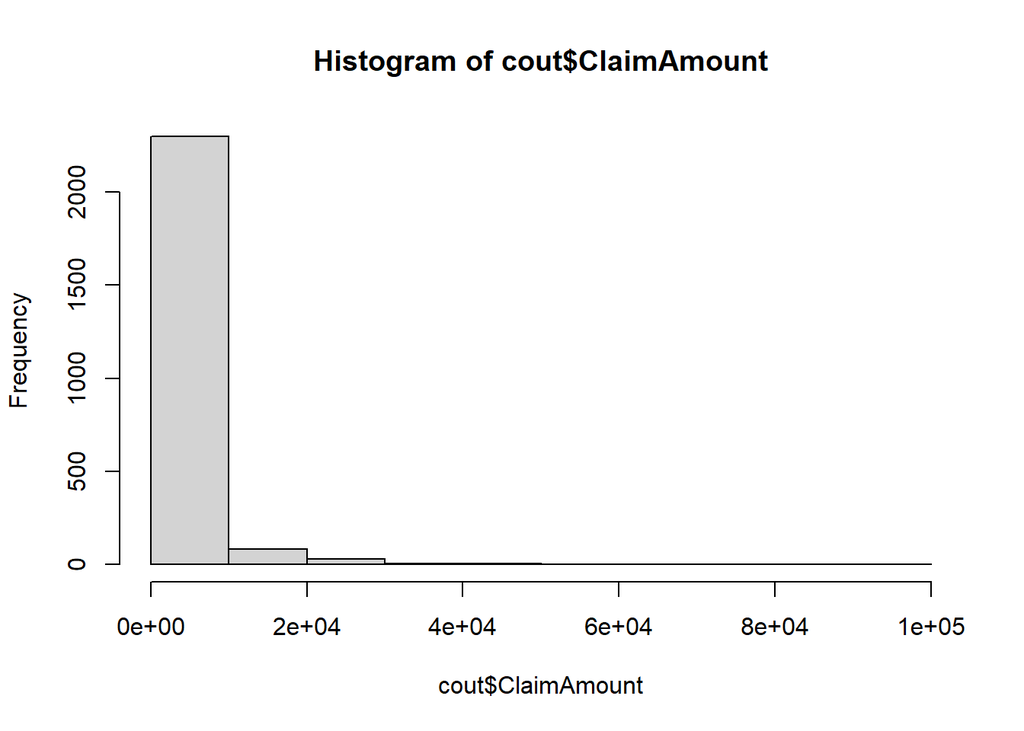

```r
hist(cout$ClaimAmount)
```

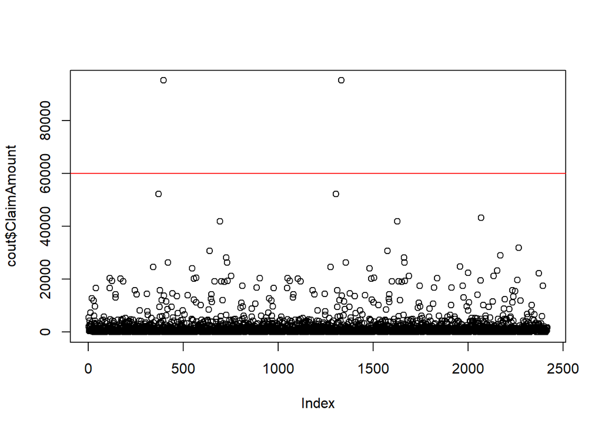

```r
plot(cout$ClaimAmount)
abline (a=60000,b=0, col ="red")
```

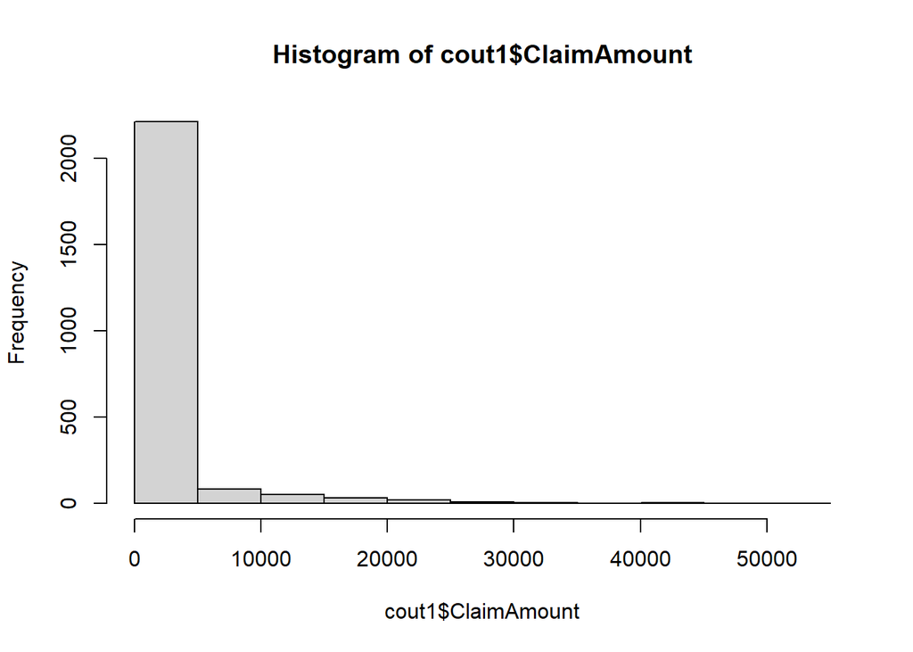

```r
#on observe dans un premier temps deux valeurs extremes qui dépassent de 47 fois la moyenne.

#Etudions toujours la répartition de la variable de sévérité privé de ces deux valeurs extrêmes.
cout1 <- subset(cout, cout$ClaimAmount <60000)
hist(cout1$ClaimAmount)
```

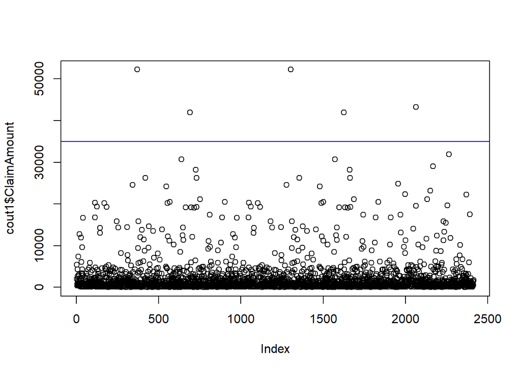

```r
plot(cout1$ClaimAmount)
abline (a=35000,b=0, col ="blue")
```

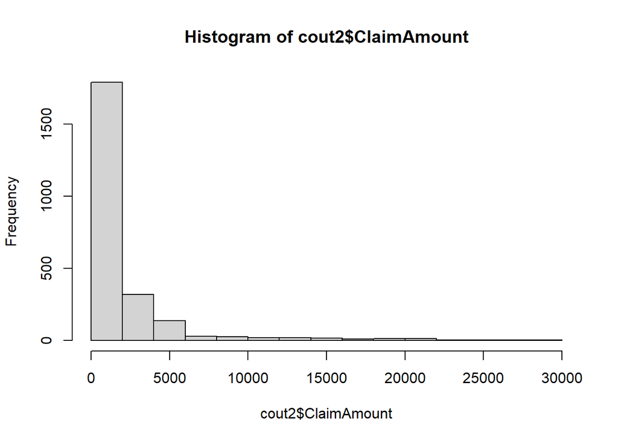

```r
#Pour une étude non biaisée vers d'autres valeurs moins extrêmes, il serait également préferable de faire une étude sur des montants inférieurs à 35000€. Seulement sept observations ont été estimées supérieures à ce prix.

cout2 <- subset(cout, cout$ClaimAmount <30000)
hist(cout2$ClaimAmount)
```

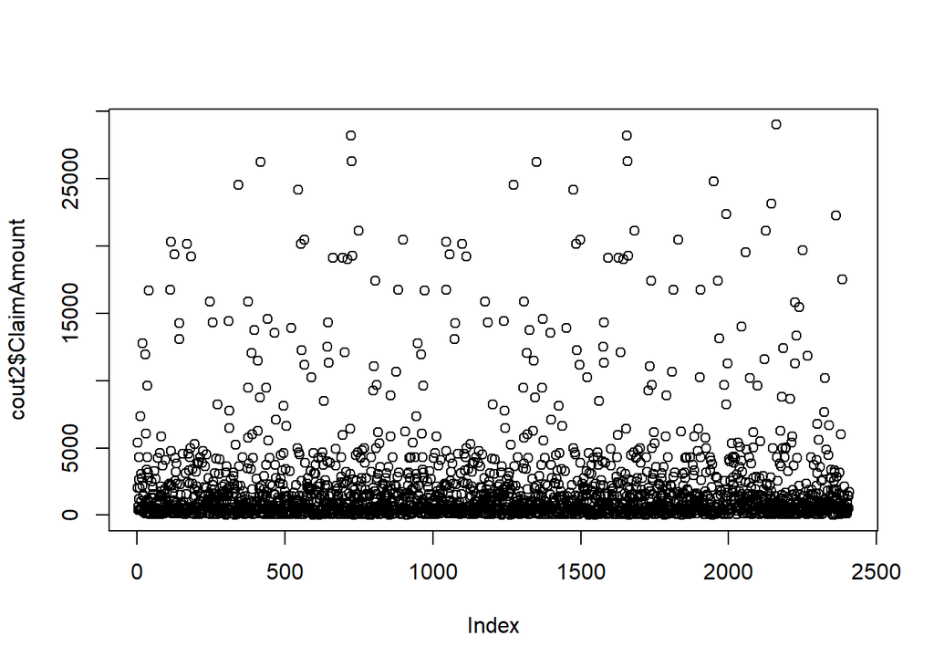

```r
plot(cout2$ClaimAmount)
```

### a) Estimation d’une loi

Dans notre étude sur la variable de sévérité ClaimAmount, nous allons essayer d’approcher la distribution de cette variable par une loi continue connue.

Nous utiliserons la méthode du qqplot

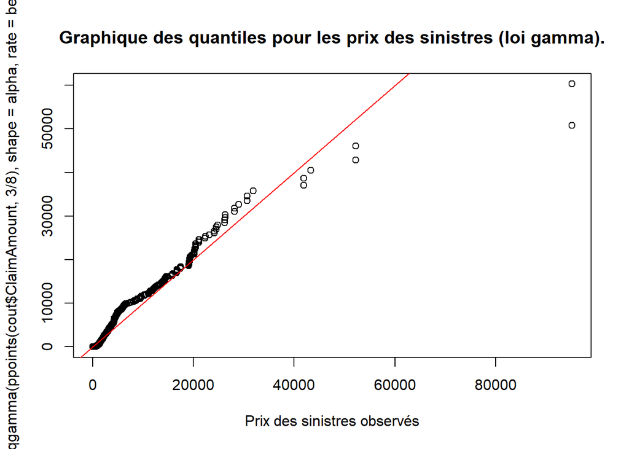

```r
#Approche par une loi Gamma
alpha = mean(cout$ClaimAmount)^2/var(cout$ClaimAmount)
beta = mean(cout$ClaimAmount)/var(cout$ClaimAmount)
qqplot (cout$ClaimAmount, qgamma ( ppoints (cout$ClaimAmount,3/8), shape =alpha, rate =beta),
            xlab ="Prix des sinistres observés",
        main ="Graphique des quantiles pour les prix des sinistres (loi gamma).")
abline (a=0,b=1, col ="red")
```

La loi gamma semble très bien s’adapter à notre modèle. De plus, une divergence avec la loi est observée lorsque les valeurs sont supérieures à 35 000. Cela nous maintient dans l’idée d’étudier notre jeu de données aux montants inférieurs à 35000.

```r
#Approche par la loi log normale
fit_params <- fitdistr(cout$ClaimAmount,"ginv")
```

```
## Error in fitdistr(cout$ClaimAmount, "ginv"): distribution non supportée
```

```r
qqplot (cout$ClaimAmount, qinv ( ppoints (cout$ClaimAmount,3/8), shape = fit_params$estimate['shape']),
            xlab ="Prix des sinistres observés",
        main ="Graphique des quantiles pour les prix des sinistres (loi log normale).")
```

```
## Error in qinv(ppoints(cout$ClaimAmount, 3/8), shape = fit_params$estimate["shape"]): impossible de trouver la fonction "qinv"
```

```r
abline (a=0,b=1, col ="red")
```

```
## Error in int_abline(a = a, b = b, h = h, v = v, untf = untf, ...): plot.new has not been called yet
```

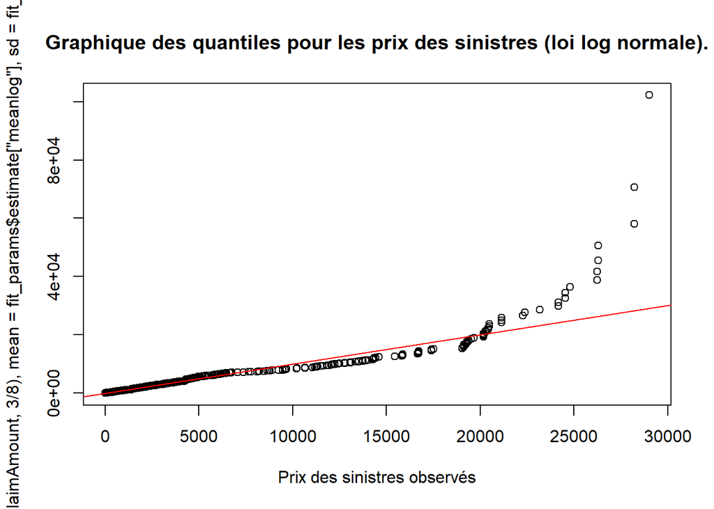

```r
#Approche par la loi log normale
fit_params <- fitdistr(cout2$ClaimAmount,"lognormal")
qqplot (cout2$ClaimAmount, qlnorm ( ppoints (cout2$ClaimAmount,3/8), mean = fit_params$estimate['meanlog'], sd = fit_params$estimate['sdlog']),
            xlab ="Prix des sinistres observés",
        main ="Graphique des quantiles pour les prix des sinistres (loi log normale).")
abline (a=0,b=1, col ="red")
```

La loi Log Normale s’ajuste assez bien sur nos données

### b)Séparation en échantillon apprentissage et échantillon test

```r
cout3 <- subset(cout, cout$ClaimAmount <20000)
set.seed(123)
perm <- sample(nrow(cout3),80/100*nrow(cout3))
train <- cout3[perm,]
test <- cout3[-perm,]
```

## III) Etude des outliers

Cette partie sera consacrée à l’étude d’outliers. Cette dernière peut s’avérer utile pour avoir un modèle le plus efficient possible. Nous avons commencé à enlever des valeurs extrêmes en limitant le domaine d’étude aux sinistres de montant inférieur à 20000€. Affinons cette recherche grâce à d’autres méthodes mises à notre disposition.

### a) Méthode d’Hampel

```r
q= 3
# calcule la borne inf de l'intervalle binf
borne_inf <- median(train$ClaimAmount) - q * mad (train$ClaimAmount)
#mad représente la déviation absolue de la médiane
borne_inf
```

```
## [1] -2149.4
```

```r
# calcule la borne sup de l'intervalle bsup
borne_sup <- median(train$ClaimAmount) + q * mad (train$ClaimAmount)
borne_sup
```

```
## [1] 3664.638
```

```r
#On renvoie les indices des outliers potentiels

indices_outliers <- which(train$ClaimAmount < borne_inf | train$ClaimAmount > borne_sup)
#indices_outliers
#length(indices_outliers)

#On renvoie les valeurs prises par nos outliers

valeurs_outliers <- train[indices_outliers,"ClaimAmount"]
#valeurs_outliers

#Puis on retire les outliers de notre échantillon

train_Hampel=slice(train,-indices_outliers)
```

Faisons un plot pour voir si certains outliers peuvent encore apparaître avec la distance de Cook

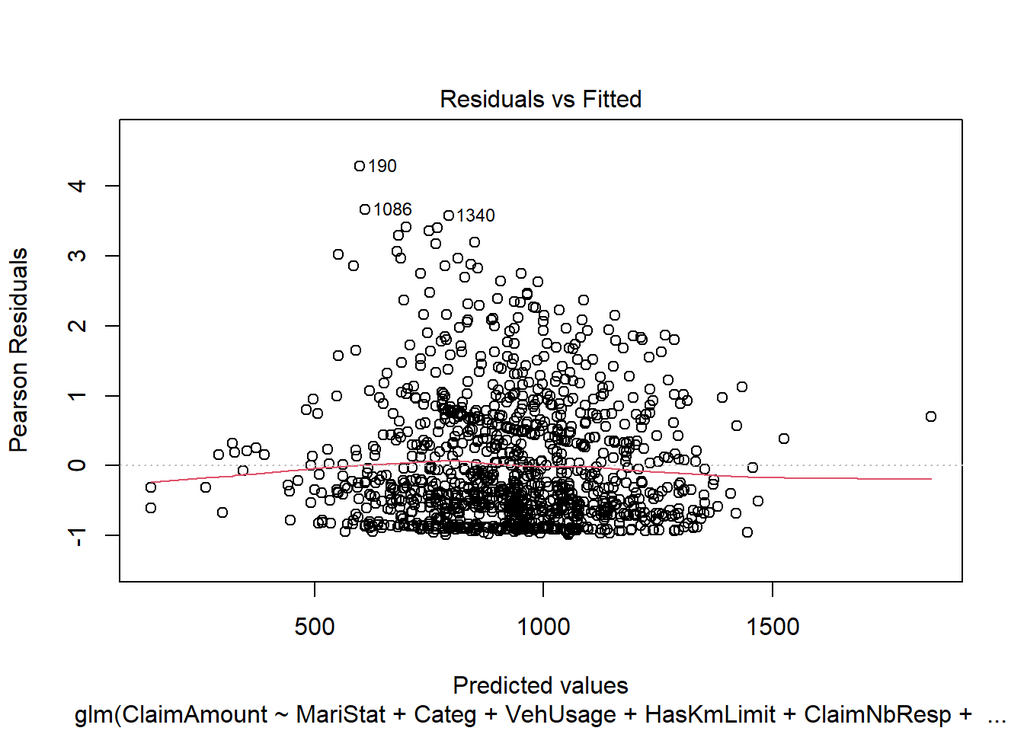

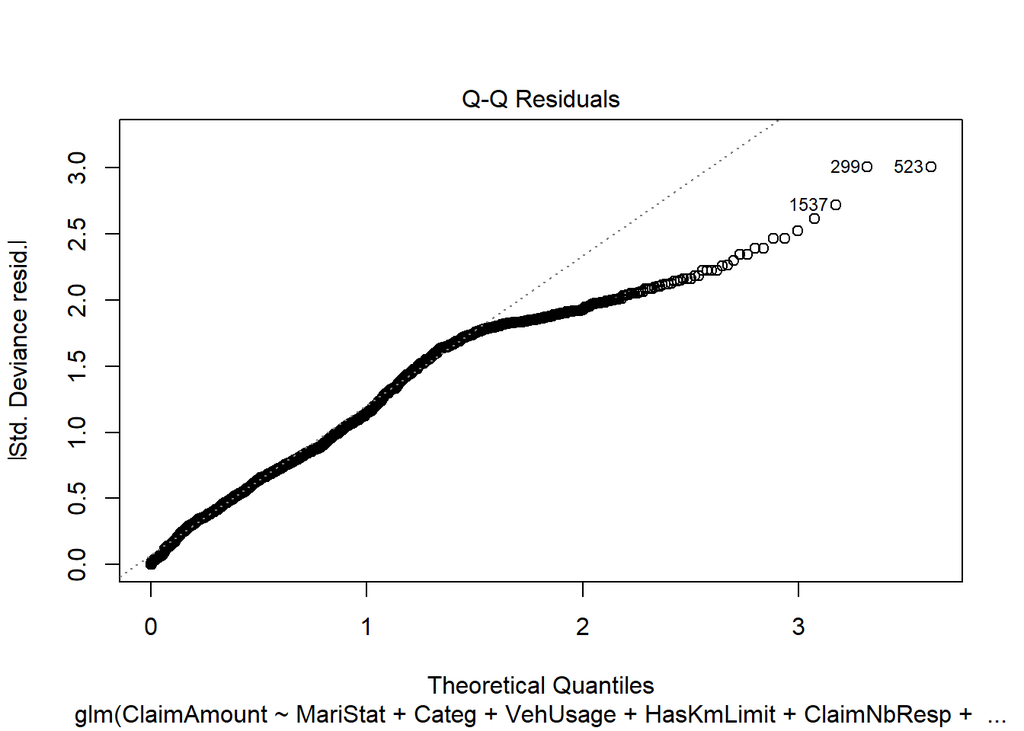

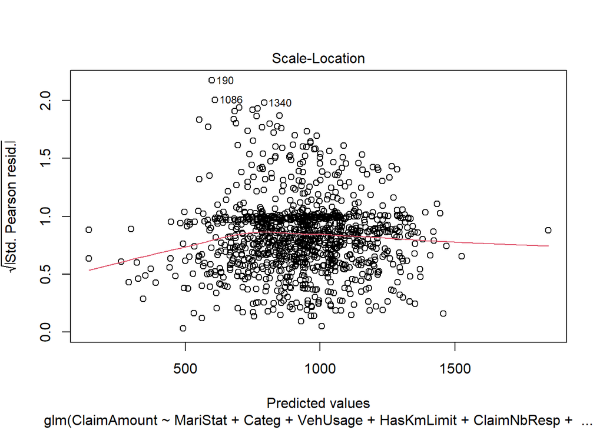

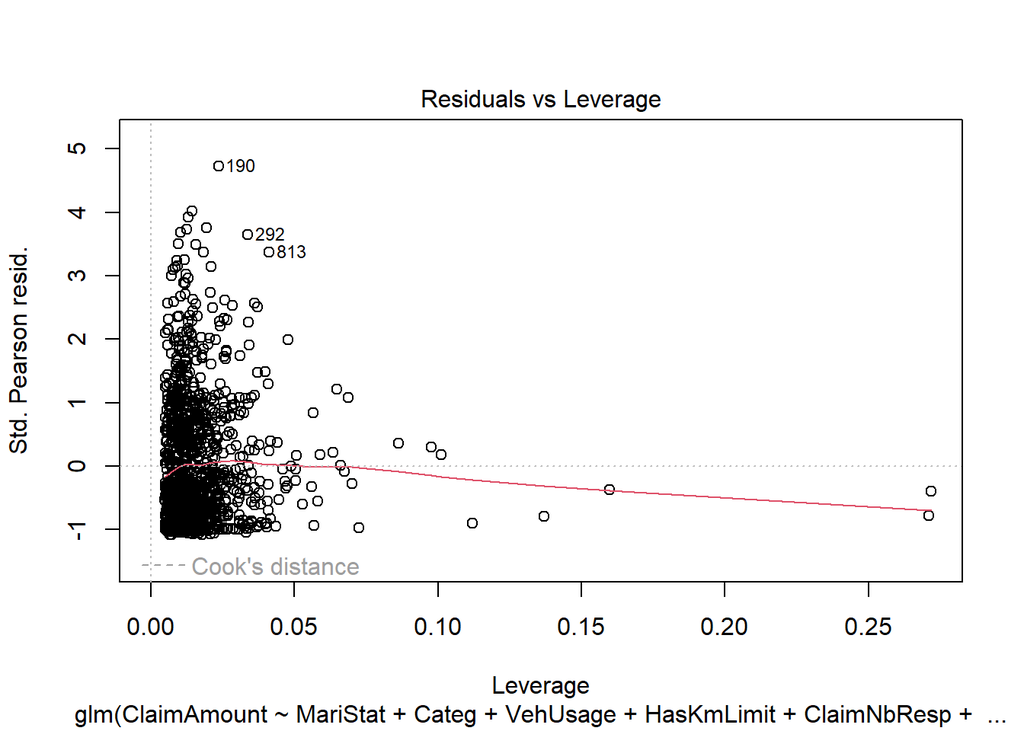

```r
plot(gamma.id_Hampel <- glm(ClaimAmount ~ MariStat+Categ+VehUsage+HasKmLimit+ClaimNbResp+ClaimNbNonResp+ClaimNbParking+ClaimNbFireTheft+ClaimNbWindscreen+OutUseNb+RiskArea+BonusMalus+DrivAge_fact, data = train_Hampel, family = Gamma(link = "identity")))
```

```r
#On effectue un test de Bonferroni
outlierTest(gamma.id_Hampel)
```

```
## No Studentized residuals with Bonferroni p < 0.05
## Largest |rstudent|:
##      rstudent unadjusted p-value Bonferroni p
## 299 -2.757786          0.0058194           NA
```

Voyons voir ce que donne le GLM gamma avec ce nouvel échantillon

```r
gamma.inv_Hampel <- glm(ClaimAmount ~ MariStat+Categ+VehUsage+HasKmLimit+ClaimNbResp+ClaimNbNonResp+ClaimNbParking+ClaimNbFireTheft+ClaimNbWindscreen+OutUseNb+RiskArea+BonusMalus+DrivAge_fact, data = train_Hampel, family = Gamma(link = "inverse"),start =rep(10e-10,28))
summary(gamma.inv_Hampel)
```

```
##
## Call:
## glm(formula = ClaimAmount ~ MariStat + Categ + VehUsage + HasKmLimit +
##     ClaimNbResp + ClaimNbNonResp + ClaimNbParking + ClaimNbFireTheft +
##     ClaimNbWindscreen + OutUseNb + RiskArea + BonusMalus + DrivAge_fact,
##     family = Gamma(link = "inverse"), data = train_Hampel, start = rep(1e-09,
##         28))
##
## Coefficients:
##                                  Estimate Std. Error t value Pr(>|t|)
## (Intercept)                     1.129e-03  2.830e-04   3.989 6.94e-05 ***
## MariStatOther                  -1.034e-04  8.336e-05  -1.240 0.215108
## CategCateg1                     3.506e-04  1.643e-04   2.134 0.033022 *
## CategCateg2                     1.238e-04  1.180e-04   1.049 0.294246
## CategCateg3                     1.411e-04  1.609e-04   0.877 0.380575
## CategCateg4                     6.946e-05  1.248e-04   0.556 0.578002
## VehUsagePrivate+trip to office  2.672e-04  7.668e-05   3.485 0.000505 ***
## VehUsageProfessional            1.238e-04  9.464e-05   1.308 0.191067
## VehUsageProfessional run        3.389e-05  1.321e-04   0.257 0.797471
## HasKmLimit1                     8.560e-06  1.129e-04   0.076 0.939563
## ClaimNbResp                    -7.457e-06  4.902e-05  -0.152 0.879115
## ClaimNbNonResp                 -8.246e-05  2.895e-05  -2.848 0.004453 **
## ClaimNbParking                 -1.405e-04  6.046e-05  -2.323 0.020286 *
## ClaimNbFireTheft               -8.859e-06  7.383e-05  -0.120 0.904501
## ClaimNbWindscreen               1.188e-04  3.792e-05   3.134 0.001755 **
## OutUseNb                       -4.079e-05  3.188e-05  -1.280 0.200892
## RiskAreaZoneRisque2            -7.897e-05  1.355e-04  -0.583 0.560182
## RiskAreaZoneRisque3            -1.589e-04  1.381e-04  -1.151 0.249945
## RiskAreaZoneRisque4             1.442e-04  1.918e-04   0.752 0.452187
## BonusMalus                     -1.795e-06  2.117e-06  -0.848 0.396502
## DrivAge_fact(25,30]            -2.115e-04  1.465e-04  -1.444 0.148914
## DrivAge_fact(30,35]            -1.782e-05  1.581e-04  -0.113 0.910260
## DrivAge_fact(35,40]             4.820e-05  1.632e-04   0.295 0.767826
## DrivAge_fact(40,45]             1.435e-05  1.654e-04   0.087 0.930875
## DrivAge_fact(45,50]            -6.714e-05  1.633e-04  -0.411 0.681113
## DrivAge_fact(50,58]            -8.676e-05  1.606e-04  -0.540 0.589153
## DrivAge_fact(58,65]             1.342e-04  1.714e-04   0.783 0.433614
## DrivAge_fact(65,120]            8.246e-05  1.867e-04   0.442 0.658776
## ---
## Signif. codes:  0 '***' 0.001 '**' 0.01 '*' 0.05 '.' 0.1 ' ' 1
##
## (Dispersion parameter for Gamma family taken to be 0.8492864)
##
##     Null deviance: 1703.7  on 1658  degrees of freedom
## Residual deviance: 1644.9  on 1631  degrees of freedom
## AIC: 25980
##
## Number of Fisher Scoring iterations: 19
```

#### b) Méthode de Tukey combiné à la méthode d’Hampel

Cette méthode se base sur l’écart interquartile et permet de détecter de potentiels outliers

```r
# Calculer l'écart interquartile (IQR)
iqr <- IQR(train_Hampel$ClaimAmount)

# Calculer les bornes de la méthode de Tukey
lower_bound <- quantile(train_Hampel$ClaimAmount, 0.25) - 1.5*iqr
upper_bound <- quantile(train_Hampel$ClaimAmount, 0.75) + 1.5*iqr

# Identifier les outliers
outliers_tukey_valeurs <- train_Hampel$ClaimAmount[train_Hampel$ClaimAmount < lower_bound | train_Hampel$ClaimAmount > upper_bound]

#On extrait les indices de ces outliers
outliers_tukey_indices <- which(train_Hampel$ClaimAmount < lower_bound | train_Hampel$ClaimAmount > upper_bound)

# Afficher les résultats
  #outliers_tukey_valeurs
  #length(outliers_tukey_valeurs)
  #outliers_tukey_indices

#On enlèves ces outliers de notre échantillon

train_Hampel_Tukey=slice(train_Hampel,-outliers_tukey_indices)
```

### c) Méthode de Tukey

```r
# Calculer l'écart interquartile (IQR)
iqr_1 <- IQR(train$ClaimAmount)

# Calculer les bornes de la méthode de Tukey
lower_bound_1 <- quantile(train$ClaimAmount, 0.25) - 1.5*iqr_1
upper_bound_1 <- quantile(train$ClaimAmount, 0.75) + 1.5*iqr_1

# Identifier les outliers
outliers_tukey_valeurs_1 <- train$ClaimAmount[train$ClaimAmount < lower_bound_1 | train$ClaimAmount > upper_bound_1]

#On extrait les indices de ces outliers
outliers_tukey_indices_1 <- which(train$ClaimAmount < lower_bound_1 | train$ClaimAmount > upper_bound_1)

# Afficher les résultats
  #outliers_tukey_valeurs_1
  #length(outliers_tukey_valeurs_1)
  #outliers_tukey_indices_1

#On enlèves ces outliers de notre échantillon

train_Tukey=slice(train,-outliers_tukey_indices_1)
```

Par la suite, nous nous servirons de ces méthodes dans nos glm pour affiner la qualité de prédiction de ces derniers.

### d) Existence d’éventuels autres outliers

Pour voir si d’autres outliers, nous nous servirons de la fonction “outliersTest”. La méthode OutliersTest consiste à calculer la distance de chaque valeur de l’ensemble de données à la moyenne ou à la médiane de l’ensemble de données. Si cette dernière est plus élevée qu’un seuil prédéfini, la valeur sera considérée comme aberrante.

```r
outlierTest(gamma.id_Hampel)
```

```
## No Studentized residuals with Bonferroni p < 0.05
## Largest |rstudent|:
##      rstudent unadjusted p-value Bonferroni p
## 299 -2.757786          0.0058194           NA
```

## IV) Loi gamma

Nous allons faire un GLM avec la loi gamma et les liens identité, inverse et log.

### A) Lien inverse

#### 1) Echantillon sans étude d’outliers / sans intéraction

```r
gamma.inv_0 <- glm(ClaimAmount ~ MariStat+Categ+VehUsage+HasKmLimit+ClaimNbResp+ClaimNbNonResp+ClaimNbParking+ClaimNbFireTheft+ClaimNbWindscreen+OutUseNb+RiskArea+BonusMalus+DrivAge_fact, data = train, family = Gamma(link = "inverse"),start =rep(10e-10,28))
summary(gamma.inv_0)
```

```
##
## Call:
## glm(formula = ClaimAmount ~ MariStat + Categ + VehUsage + HasKmLimit +
##     ClaimNbResp + ClaimNbNonResp + ClaimNbParking + ClaimNbFireTheft +
##     ClaimNbWindscreen + OutUseNb + RiskArea + BonusMalus + DrivAge_fact,
##     family = Gamma(link = "inverse"), data = train, start = rep(1e-09,
##         28))
##
## Coefficients:
##                                  Estimate Std. Error t value Pr(>|t|)
## (Intercept)                     7.225e-04  2.292e-04   3.152 0.001648 **
## MariStatOther                   7.014e-05  4.852e-05   1.446 0.148484
## CategCateg1                    -2.565e-06  1.305e-04  -0.020 0.984323
## CategCateg2                    -2.105e-05  1.057e-04  -0.199 0.842182
## CategCateg3                     1.418e-04  1.344e-04   1.055 0.291578
## CategCateg4                     6.310e-05  1.121e-04   0.563 0.573653
## VehUsagePrivate+trip to office  1.136e-04  5.365e-05   2.118 0.034307 *
## VehUsageProfessional            2.612e-05  7.084e-05   0.369 0.712337
## VehUsageProfessional run        2.236e-05  1.124e-04   0.199 0.842371
## HasKmLimit1                    -6.570e-05  6.883e-05  -0.954 0.339958
## ClaimNbResp                    -1.038e-04  2.852e-05  -3.641 0.000279 ***
## ClaimNbNonResp                 -6.768e-05  2.318e-05  -2.920 0.003547 **
## ClaimNbParking                  1.918e-05  5.577e-05   0.344 0.730886
## ClaimNbFireTheft               -6.001e-05  4.485e-05  -1.338 0.181040
## ClaimNbWindscreen               2.107e-05  2.856e-05   0.738 0.460841
## OutUseNb                        1.403e-05  2.593e-05   0.541 0.588467
## RiskAreaZoneRisque2            -2.213e-04  1.557e-04  -1.422 0.155293
## RiskAreaZoneRisque3            -3.138e-04  1.562e-04  -2.009 0.044700 *
## RiskAreaZoneRisque4            -2.080e-05  2.039e-04  -0.102 0.918740
## BonusMalus                     -8.124e-07  1.287e-06  -0.631 0.527995
## DrivAge_fact(25,30]            -4.053e-05  8.796e-05  -0.461 0.645007
## DrivAge_fact(30,35]             2.614e-04  1.180e-04   2.215 0.026900 *
## DrivAge_fact(35,40]             3.364e-04  1.266e-04   2.658 0.007935 **
## DrivAge_fact(40,45]             8.659e-05  1.048e-04   0.826 0.408873
## DrivAge_fact(45,50]             7.928e-05  1.087e-04   0.729 0.465951
## DrivAge_fact(50,58]             2.419e-05  1.039e-04   0.233 0.815966
## DrivAge_fact(58,65]             1.148e-04  1.139e-04   1.008 0.313492
## DrivAge_fact(65,120]           -2.289e-05  1.170e-04  -0.196 0.844884
## ---
## Signif. codes:  0 '***' 0.001 '**' 0.01 '*' 0.05 '.' 0.1 ' ' 1
##
## (Dispersion parameter for Gamma family taken to be 2.388257)
##
##     Null deviance: 3286.8  on 1903  degrees of freedom
## Residual deviance: 3051.5  on 1876  degrees of freedom
## AIC: 32118
##
## Number of Fisher Scoring iterations: 18
```

La commande “start =rep(10e-10,28)” permet de donner une valeur inititale aux coefficients que l’on cherche à estimer. Sans cette commande, le code renvoie un message d’erreur

Nous verrons par la suite que nos modèles appliqués aux données issues de la méthode d’Hampel et du Tukey nous permettent de palier ce problème.

#### 2) Echantillon sans étude d’outliers / avec intéractions

Après avoir testé de nombreuses interactions entre les variables, l’interaction “ClaimNbNonResp*ClaimNbResp” est celle qui a davantage d’impact sur le modèle et permet l’apparition d’un paramètre de p valeur inférieur à 0.05

```r
gamma.inv_1 <- glm(ClaimAmount ~ MariStat+Categ+VehUsage+HasKmLimit+ClaimNbResp+ClaimNbNonResp+ClaimNbParking+ClaimNbFireTheft+ClaimNbWindscreen+OutUseNb+RiskArea+BonusMalus+DrivAge_fact+ClaimNbNonResp*ClaimNbResp,data = train, family = Gamma(link = "inverse"),start =rep(10e-10,29))
summary(gamma.inv_1)
```

```
##
## Call:
## glm(formula = ClaimAmount ~ MariStat + Categ + VehUsage + HasKmLimit +
##     ClaimNbResp + ClaimNbNonResp + ClaimNbParking + ClaimNbFireTheft +
##     ClaimNbWindscreen + OutUseNb + RiskArea + BonusMalus + DrivAge_fact +
##     ClaimNbNonResp * ClaimNbResp, family = Gamma(link = "inverse"),
##     data = train, start = rep(1e-09, 29))
##
## Coefficients:
##                                  Estimate Std. Error t value Pr(>|t|)
## (Intercept)                     7.408e-04  2.300e-04   3.221   0.0013 **
## MariStatOther                   9.199e-05  5.124e-05   1.795   0.0727 .
## CategCateg1                     2.213e-06  1.303e-04   0.017   0.9864
## CategCateg2                    -1.216e-05  1.061e-04  -0.115   0.9088
## CategCateg3                     1.387e-04  1.350e-04   1.028   0.3043
## CategCateg4                     7.463e-05  1.125e-04   0.663   0.5073
## VehUsagePrivate+trip to office  1.071e-04  5.445e-05   1.967   0.0493 *
## VehUsageProfessional            2.868e-05  7.014e-05   0.409   0.6826
## VehUsageProfessional run        6.046e-06  1.149e-04   0.053   0.9580
## HasKmLimit1                    -4.939e-05  6.789e-05  -0.727   0.4671
## ClaimNbResp                    -1.369e-04  3.032e-05  -4.516 6.71e-06 ***
## ClaimNbNonResp                 -1.071e-04  2.664e-05  -4.020 6.05e-05 ***
## ClaimNbParking                  2.898e-05  5.444e-05   0.532   0.5946
## ClaimNbFireTheft               -6.556e-05  4.560e-05  -1.438   0.1507
## ClaimNbWindscreen               2.320e-05  2.848e-05   0.814   0.4155
## OutUseNb                        1.824e-05  2.491e-05   0.732   0.4643
## RiskAreaZoneRisque2            -2.146e-04  1.562e-04  -1.374   0.1695
## RiskAreaZoneRisque3            -3.165e-04  1.567e-04  -2.020   0.0435 *
## RiskAreaZoneRisque4            -2.269e-05  2.042e-04  -0.111   0.9115
## BonusMalus                     -8.762e-07  1.277e-06  -0.686   0.4926
## DrivAge_fact(25,30]            -3.812e-05  8.655e-05  -0.440   0.6597
## DrivAge_fact(30,35]             2.418e-04  1.170e-04   2.067   0.0389 *
## DrivAge_fact(35,40]             3.162e-04  1.253e-04   2.523   0.0117 *
## DrivAge_fact(40,45]             5.540e-05  1.032e-04   0.537   0.5915
## DrivAge_fact(45,50]             5.447e-05  1.080e-04   0.504   0.6140
## DrivAge_fact(50,58]            -1.499e-07  1.028e-04  -0.001   0.9988
## DrivAge_fact(58,65]             9.817e-05  1.128e-04   0.870   0.3844
## DrivAge_fact(65,120]           -5.698e-05  1.189e-04  -0.479   0.6318
## ClaimNbResp:ClaimNbNonResp      5.990e-05  2.901e-05   2.065   0.0390 *
## ---
## Signif. codes:  0 '***' 0.001 '**' 0.01 '*' 0.05 '.' 0.1 ' ' 1
##
## (Dispersion parameter for Gamma family taken to be 2.403339)
##
##     Null deviance: 3286.8  on 1903  degrees of freedom
## Residual deviance: 3040.4  on 1875  degrees of freedom
## AIC: 32112
##
## Number of Fisher Scoring iterations: 18
```

##### Comparaison AIC entre le modèle réduit à l’intercept et plein

```r
mod0_gamma_inv_0 <- glm(ClaimAmount ~ 1, data = train, family = Gamma(link = "inverse"))
AIC(mod0_gamma_inv_0)
```

```
## [1] 32238.99
```

```r
modBoth_gamma_inv_1 = step(gamma.inv_1, mod0_gamma_inv_0, trace=F,direction = c('both'), start=rep(10e-10,29))
```

```
## Error: impossible de trouver un jeu de coefficients correct : prière de fournir des valeurs initiales
```

Nous ne nous éterniserons pas davantage sur ce message d’erreur. En effet, cela marchera davantage avec d’autres données

#### 4) Echantillon avec études d’outliers et intéractions : Hampel

```r
gamma.inv_Hampel_0<- glm(ClaimAmount ~ MariStat+Categ+VehUsage+HasKmLimit+ClaimNbResp+ClaimNbNonResp+ClaimNbParking+ClaimNbFireTheft+ClaimNbWindscreen+OutUseNb+RiskArea+BonusMalus+DrivAge_fact+ClaimNbNonResp*ClaimNbResp,data = train_Hampel, family = Gamma(link = "inverse"))
summary(gamma.inv_Hampel_0)
```

```
##
## Call:
## glm(formula = ClaimAmount ~ MariStat + Categ + VehUsage + HasKmLimit +
##     ClaimNbResp + ClaimNbNonResp + ClaimNbParking + ClaimNbFireTheft +
##     ClaimNbWindscreen + OutUseNb + RiskArea + BonusMalus + DrivAge_fact +
##     ClaimNbNonResp * ClaimNbResp, family = Gamma(link = "inverse"),
##     data = train_Hampel)
##
## Coefficients:
##                                  Estimate Std. Error t value Pr(>|t|)
## (Intercept)                     1.136e-03  2.831e-04   4.013 6.27e-05 ***
## MariStatOther                  -1.017e-04  8.349e-05  -1.218 0.223479
## CategCateg1                     3.456e-04  1.644e-04   2.103 0.035658 *
## CategCateg2                     1.207e-04  1.181e-04   1.022 0.306820
## CategCateg3                     1.376e-04  1.609e-04   0.855 0.392870
## CategCateg4                     6.984e-05  1.248e-04   0.560 0.575840
## VehUsagePrivate+trip to office  2.644e-04  7.675e-05   3.445 0.000584 ***
## VehUsageProfessional            1.254e-04  9.459e-05   1.326 0.184964
## VehUsageProfessional run        3.257e-05  1.319e-04   0.247 0.805013
## HasKmLimit1                     7.661e-06  1.127e-04   0.068 0.945832
## ClaimNbResp                    -3.077e-05  5.572e-05  -0.552 0.580948
## ClaimNbNonResp                 -9.339e-05  3.003e-05  -3.110 0.001900 **
## ClaimNbParking                 -1.393e-04  6.043e-05  -2.305 0.021297 *
## ClaimNbFireTheft               -9.591e-06  7.383e-05  -0.130 0.896648
## ClaimNbWindscreen               1.182e-04  3.788e-05   3.119 0.001844 **
## OutUseNb                       -3.832e-05  3.202e-05  -1.197 0.231575
## RiskAreaZoneRisque2            -7.877e-05  1.355e-04  -0.581 0.561083
## RiskAreaZoneRisque3            -1.588e-04  1.380e-04  -1.150 0.250197
## RiskAreaZoneRisque4             1.427e-04  1.918e-04   0.744 0.456875
## BonusMalus                     -1.789e-06  2.113e-06  -0.847 0.397397
## DrivAge_fact(25,30]            -2.101e-04  1.464e-04  -1.435 0.151463
## DrivAge_fact(30,35]            -1.784e-05  1.581e-04  -0.113 0.910181
## DrivAge_fact(35,40]             4.818e-05  1.631e-04   0.295 0.767696
## DrivAge_fact(40,45]             1.104e-05  1.654e-04   0.067 0.946805
## DrivAge_fact(45,50]            -6.596e-05  1.634e-04  -0.404 0.686484
## DrivAge_fact(50,58]            -8.883e-05  1.607e-04  -0.553 0.580448
## DrivAge_fact(58,65]             1.355e-04  1.715e-04   0.790 0.429372
## DrivAge_fact(65,120]            8.252e-05  1.871e-04   0.441 0.659212
## ClaimNbResp:ClaimNbNonResp      4.198e-05  5.105e-05   0.822 0.410987
## ---
## Signif. codes:  0 '***' 0.001 '**' 0.01 '*' 0.05 '.' 0.1 ' ' 1
##
## (Dispersion parameter for Gamma family taken to be 0.8487664)
##
##     Null deviance: 1703.7  on 1658  degrees of freedom
## Residual deviance: 1644.3  on 1630  degrees of freedom
## AIC: 25981
##
## Number of Fisher Scoring iterations: 6
```

Nous voyons que nous n’avons plus besoin de fournir un jeu de données de départ.

##### Comparaison AIC entre le modèle réduit à l’intercept et plein

```r
mod0_gamma_inv_Hampel <- glm(ClaimAmount ~ 1, data = train_Hampel, family = Gamma(link = "inverse"))
AIC(mod0_gamma_inv_Hampel)
```

```
## [1] 25993.21
```

```r
modBoth_gamma_inv_Hampel = step(gamma.inv_Hampel_0, mod0_gamma_inv_Hampel, trace=F,direction = c('both'))
summary(modBoth_gamma_inv_Hampel)
```

```
##
## Call:
## glm(formula = ClaimAmount ~ VehUsage + ClaimNbNonResp + ClaimNbParking +
##     ClaimNbWindscreen + OutUseNb + BonusMalus, family = Gamma(link = "inverse"),
##     data = train_Hampel)
##
## Coefficients:
##                                  Estimate Std. Error t value Pr(>|t|)
## (Intercept)                     1.162e-03  9.678e-05  12.009  < 2e-16 ***
## VehUsagePrivate+trip to office  1.890e-04  5.940e-05   3.182 0.001488 **
## VehUsageProfessional            5.126e-05  6.783e-05   0.756 0.449973
## VehUsageProfessional run       -7.459e-05  1.047e-04  -0.712 0.476262
## ClaimNbNonResp                 -8.758e-05  2.820e-05  -3.106 0.001929 **
## ClaimNbParking                 -1.332e-04  6.010e-05  -2.216 0.026824 *
## ClaimNbWindscreen               1.270e-04  3.732e-05   3.402 0.000685 ***
## OutUseNb                       -4.834e-05  3.186e-05  -1.517 0.129379
## BonusMalus                     -2.654e-06  1.478e-06  -1.796 0.072626 .
## ---
## Signif. codes:  0 '***' 0.001 '**' 0.01 '*' 0.05 '.' 0.1 ' ' 1
##
## (Dispersion parameter for Gamma family taken to be 0.8529751)
##
##     Null deviance: 1703.7  on 1658  degrees of freedom
## Residual deviance: 1666.9  on 1650  degrees of freedom
## AIC: 25967
##
## Number of Fisher Scoring iterations: 6
```

L’écart d’AIC entre les modèle réduit à l’intercept et both n’est pas conséquent.

#### 5) Echantillon avec études d’outliers et intéractions : Tukey

```r
gamma.inv_Tukey<- glm(ClaimAmount ~ MariStat+Categ+VehUsage+HasKmLimit+ClaimNbResp+ClaimNbNonResp+ClaimNbParking+ClaimNbFireTheft+ClaimNbWindscreen+OutUseNb+RiskArea+BonusMalus+DrivAge_fact+ClaimNbNonResp*ClaimNbResp,data = train_Tukey, family = Gamma(link = "inverse"))
summary(gamma.inv_Tukey)
```

```
##
## Call:
## glm(formula = ClaimAmount ~ MariStat + Categ + VehUsage + HasKmLimit +
##     ClaimNbResp + ClaimNbNonResp + ClaimNbParking + ClaimNbFireTheft +
##     ClaimNbWindscreen + OutUseNb + RiskArea + BonusMalus + DrivAge_fact +
##     ClaimNbNonResp * ClaimNbResp, family = Gamma(link = "inverse"),
##     data = train_Tukey)
##
## Coefficients:
##                                  Estimate Std. Error t value Pr(>|t|)
## (Intercept)                     1.508e-03  2.673e-04   5.643 1.96e-08 ***
## MariStatOther                  -1.327e-04  7.876e-05  -1.685 0.092265 .
## CategCateg1                     2.667e-04  1.493e-04   1.786 0.074266 .
## CategCateg2                     6.347e-05  1.102e-04   0.576 0.564741
## CategCateg3                     9.952e-05  1.458e-04   0.683 0.494979
## CategCateg4                     4.912e-05  1.134e-04   0.433 0.664881
## VehUsagePrivate+trip to office  2.032e-04  6.748e-05   3.011 0.002642 **
## VehUsageProfessional            9.197e-05  8.407e-05   1.094 0.274171
## VehUsageProfessional run       -1.817e-05  1.156e-04  -0.157 0.875151
## HasKmLimit1                    -1.701e-04  8.424e-05  -2.019 0.043608 *
## ClaimNbResp                    -5.198e-05  4.458e-05  -1.166 0.243738
## ClaimNbNonResp                 -8.517e-05  2.954e-05  -2.883 0.003991 **
## ClaimNbParking                 -7.182e-05  5.996e-05  -1.198 0.231124
## ClaimNbFireTheft               -6.572e-05  6.091e-05  -1.079 0.280796
## ClaimNbWindscreen               1.163e-04  3.502e-05   3.321 0.000915 ***
## OutUseNb                       -4.916e-05  2.687e-05  -1.829 0.067513 .
## RiskAreaZoneRisque2            -1.920e-04  1.415e-04  -1.357 0.175091
## RiskAreaZoneRisque3            -2.801e-04  1.433e-04  -1.955 0.050785 .
## RiskAreaZoneRisque4            -3.399e-06  1.904e-04  -0.018 0.985758
## BonusMalus                     -3.318e-06  1.756e-06  -1.890 0.058944 .
## DrivAge_fact(25,30]            -2.803e-04  1.494e-04  -1.876 0.060772 .
## DrivAge_fact(30,35]            -7.796e-05  1.617e-04  -0.482 0.629823
## DrivAge_fact(35,40]            -3.524e-05  1.634e-04  -0.216 0.829233
## DrivAge_fact(40,45]            -1.779e-04  1.622e-04  -1.097 0.272855
## DrivAge_fact(45,50]            -2.560e-04  1.592e-04  -1.608 0.108056
## DrivAge_fact(50,58]            -2.939e-04  1.584e-04  -1.855 0.063725 .
## DrivAge_fact(58,65]            -1.833e-04  1.634e-04  -1.122 0.261985
## DrivAge_fact(65,120]           -1.189e-05  1.805e-04  -0.066 0.947475
## ClaimNbResp:ClaimNbNonResp      2.653e-06  3.526e-05   0.075 0.940034
## ---
## Signif. codes:  0 '***' 0.001 '**' 0.01 '*' 0.05 '.' 0.1 ' ' 1
##
## (Dispersion parameter for Gamma family taken to be 0.9558312)
##
##     Null deviance: 1959.4  on 1733  degrees of freedom
## Residual deviance: 1864.8  on 1705  degrees of freedom
## AIC: 27617
##
## Number of Fisher Scoring iterations: 6
```

##### Comparaison AIC entre le modèle réduit à l’intercept et plein

```r
mod0_gamma_inv_Tukey <- glm(ClaimAmount ~ 1, data = train_Tukey, family = Gamma(link = "inverse"))
AIC(mod0_gamma_inv_Tukey)
```

```
## [1] 27660.91
```

```r
modBoth_gamma_inv_Tukey = step(gamma.inv_Tukey, mod0_gamma_inv_Tukey, trace=F,direction = c('both'))
summary(modBoth_gamma_inv_Tukey)
```

```
##
## Call:
## glm(formula = ClaimAmount ~ MariStat + VehUsage + HasKmLimit +
##     ClaimNbNonResp + ClaimNbWindscreen + OutUseNb + RiskArea +
##     BonusMalus + DrivAge_fact, family = Gamma(link = "inverse"),
##     data = train_Tukey)
##
## Coefficients:
##                                  Estimate Std. Error t value Pr(>|t|)
## (Intercept)                     1.653e-03  2.352e-04   7.028 3.01e-12 ***
## MariStatOther                  -1.347e-04  7.831e-05  -1.720 0.085659 .
## VehUsagePrivate+trip to office  1.875e-04  6.169e-05   3.039 0.002410 **
## VehUsageProfessional            9.250e-05  6.869e-05   1.347 0.178246
## VehUsageProfessional run       -7.185e-05  9.453e-05  -0.760 0.447347
## HasKmLimit1                    -1.711e-04  8.398e-05  -2.038 0.041716 *
## ClaimNbNonResp                 -8.779e-05  2.553e-05  -3.439 0.000597 ***
## ClaimNbWindscreen               1.173e-04  3.458e-05   3.393 0.000708 ***
## OutUseNb                       -4.606e-05  2.689e-05  -1.713 0.086980 .
## RiskAreaZoneRisque2            -2.001e-04  1.403e-04  -1.426 0.153922
## RiskAreaZoneRisque3            -2.883e-04  1.417e-04  -2.034 0.042086 *
## RiskAreaZoneRisque4            -2.526e-05  1.889e-04  -0.134 0.893653
## BonusMalus                     -4.379e-06  1.483e-06  -2.953 0.003190 **
## DrivAge_fact(25,30]            -2.881e-04  1.477e-04  -1.950 0.051341 .
## DrivAge_fact(30,35]            -8.738e-05  1.589e-04  -0.550 0.582353
## DrivAge_fact(35,40]            -4.734e-05  1.599e-04  -0.296 0.767159
## DrivAge_fact(40,45]            -2.047e-04  1.578e-04  -1.298 0.194555
## DrivAge_fact(45,50]            -2.830e-04  1.552e-04  -1.824 0.068389 .
## DrivAge_fact(50,58]            -3.159e-04  1.531e-04  -2.064 0.039167 *
## DrivAge_fact(58,65]            -2.037e-04  1.566e-04  -1.301 0.193382
## DrivAge_fact(65,120]           -2.809e-05  1.634e-04  -0.172 0.863515
## ---
## Signif. codes:  0 '***' 0.001 '**' 0.01 '*' 0.05 '.' 0.1 ' ' 1
##
## (Dispersion parameter for Gamma family taken to be 0.9474524)
##
##     Null deviance: 1959.4  on 1733  degrees of freedom
## Residual deviance: 1873.0  on 1713  degrees of freedom
## AIC: 27609
##
## Number of Fisher Scoring iterations: 6
```

### B) Lien log

#### 1) Echantillon sans étude d’outliers / sans intéraction

```r
gamma.log_0 <- glm(ClaimAmount ~ MariStat+Categ+VehUsage+HasKmLimit+ClaimNbResp+ClaimNbNonResp+ClaimNbParking+ClaimNbFireTheft+ClaimNbWindscreen+OutUseNb+RiskArea+BonusMalus+DrivAge_fact, data = train, family = Gamma(link = "log"))
summary(gamma.log_0)
```

```
##
## Call:
## glm(formula = ClaimAmount ~ MariStat + Categ + VehUsage + HasKmLimit +
##     ClaimNbResp + ClaimNbNonResp + ClaimNbParking + ClaimNbFireTheft +
##     ClaimNbWindscreen + OutUseNb + RiskArea + BonusMalus + DrivAge_fact,
##     family = Gamma(link = "log"), data = train)
##
## Coefficients:
##                                 Estimate Std. Error t value Pr(>|t|)
## (Intercept)                     7.135813   0.418924  17.034  < 2e-16 ***
## MariStatOther                  -0.198785   0.116399  -1.708  0.08784 .
## CategCateg1                     0.052061   0.242154   0.215  0.82980
## CategCateg2                     0.141898   0.193093   0.735  0.46251
## CategCateg3                    -0.218992   0.255317  -0.858  0.39115
## CategCateg4                    -0.054041   0.208892  -0.259  0.79589
## VehUsagePrivate+trip to office -0.328734   0.126501  -2.599  0.00943 **
## VehUsageProfessional           -0.082354   0.152896  -0.539  0.59021
## VehUsageProfessional run       -0.026856   0.217963  -0.123  0.90195
## HasKmLimit1                     0.227047   0.163755   1.387  0.16576
## ClaimNbResp                     0.229863   0.069441   3.310  0.00095 ***
## ClaimNbNonResp                  0.158255   0.055000   2.877  0.00406 **
## ClaimNbParking                  0.044719   0.104518   0.428  0.66880
## ClaimNbFireTheft                0.146827   0.109283   1.344  0.17926
## ClaimNbWindscreen              -0.074767   0.048728  -1.534  0.12511
## OutUseNb                       -0.020365   0.053440  -0.381  0.70319
## RiskAreaZoneRisque2             0.345160   0.191725   1.800  0.07198 .
## RiskAreaZoneRisque3             0.505832   0.196622   2.573  0.01017 *
## RiskAreaZoneRisque4             0.055128   0.248934   0.221  0.82476
## BonusMalus                      0.003641   0.003040   1.198  0.23123
## DrivAge_fact(25,30]             0.093164   0.221912   0.420  0.67466
## DrivAge_fact(30,35]            -0.413978   0.228802  -1.809  0.07056 .
## DrivAge_fact(35,40]            -0.518145   0.234233  -2.212  0.02708 *
## DrivAge_fact(40,45]            -0.100478   0.236399  -0.425  0.67086
## DrivAge_fact(45,50]            -0.068059   0.238917  -0.285  0.77578
## DrivAge_fact(50,58]            -0.016060   0.233090  -0.069  0.94508
## DrivAge_fact(58,65]            -0.129877   0.245367  -0.529  0.59665
## DrivAge_fact(65,120]            0.037961   0.273134   0.139  0.88948
## ---
## Signif. codes:  0 '***' 0.001 '**' 0.01 '*' 0.05 '.' 0.1 ' ' 1
##
## (Dispersion parameter for Gamma family taken to be 2.388153)
##
##     Null deviance: 3286.8  on 1903  degrees of freedom
## Residual deviance: 3038.4  on 1876  degrees of freedom
## AIC: 32108
##
## Number of Fisher Scoring iterations: 9
```

#### 2) Echantillon sans étude d’outliers / avec intéraction

```r
gamma.log_1 <- glm(ClaimAmount ~ MariStat+Categ+VehUsage+HasKmLimit+ClaimNbResp+ClaimNbNonResp+ClaimNbParking+ClaimNbFireTheft+ClaimNbWindscreen+OutUseNb+RiskArea+BonusMalus+DrivAge_fact+DrivAge_fact*RiskArea+RiskArea*MariStat+ClaimNbResp*ClaimNbNonResp,data = train, family = Gamma(link = "log"))
summary(gamma.log_1)
```

```
##
## Call:
## glm(formula = ClaimAmount ~ MariStat + Categ + VehUsage + HasKmLimit +
##     ClaimNbResp + ClaimNbNonResp + ClaimNbParking + ClaimNbFireTheft +
##     ClaimNbWindscreen + OutUseNb + RiskArea + BonusMalus + DrivAge_fact +
##     DrivAge_fact * RiskArea + RiskArea * MariStat + ClaimNbResp *
##     ClaimNbNonResp, family = Gamma(link = "log"), data = train)
##
## Coefficients:
##                                           Estimate Std. Error t value Pr(>|t|)
## (Intercept)                               5.088134   1.217991   4.177 3.08e-05
## MariStatOther                            -0.790186   0.525894  -1.503 0.133124
## CategCateg1                               0.066017   0.232225   0.284 0.776228
## CategCateg2                               0.155117   0.185741   0.835 0.403755
## CategCateg3                              -0.252299   0.244515  -1.032 0.302284
## CategCateg4                              -0.077465   0.200691  -0.386 0.699547
## VehUsagePrivate+trip to office           -0.261097   0.122003  -2.140 0.032478
## VehUsageProfessional                     -0.043331   0.147091  -0.295 0.768345
## VehUsageProfessional run                  0.028089   0.211254   0.133 0.894236
## HasKmLimit1                               0.230937   0.157652   1.465 0.143132
## ClaimNbResp                               0.259001   0.076525   3.385 0.000728
## ClaimNbNonResp                            0.182419   0.061760   2.954 0.003180
## ClaimNbParking                            0.057140   0.101110   0.565 0.572060
## ClaimNbFireTheft                          0.113321   0.104482   1.085 0.278244
## ClaimNbWindscreen                        -0.107343   0.047030  -2.282 0.022577
## OutUseNb                                 -0.056145   0.051319  -1.094 0.274082
## RiskAreaZoneRisque2                       2.697015   1.192144   2.262 0.023793
## RiskAreaZoneRisque3                       1.699751   1.202950   1.413 0.157829
## RiskAreaZoneRisque4                       2.196614   1.325146   1.658 0.097560
## BonusMalus                                0.003155   0.002978   1.060 0.289405
## DrivAge_fact(25,30]                       2.575233   1.358584   1.896 0.058179
## DrivAge_fact(30,35]                       2.340692   1.194706   1.959 0.050237
## DrivAge_fact(35,40]                       2.430990   1.170734   2.076 0.037989
## DrivAge_fact(40,45]                       2.308510   1.474469   1.566 0.117601
## DrivAge_fact(45,50]                       1.793251   1.475161   1.216 0.224281
## DrivAge_fact(50,58]                       2.447654   1.097858   2.229 0.025902
## DrivAge_fact(58,65]                       2.330891   1.144333   2.037 0.041802
## DrivAge_fact(65,120]                      2.668733   1.124674   2.373 0.017751
## RiskAreaZoneRisque2:DrivAge_fact(25,30]  -3.332104   1.389264  -2.398 0.016562
## RiskAreaZoneRisque3:DrivAge_fact(25,30]  -1.255714   1.402387  -0.895 0.370683
```

[output cut: 78 more lines]

```
## RiskAreaZoneRisque4:DrivAge_fact(65,120] *
## MariStatOther:RiskAreaZoneRisque2
## MariStatOther:RiskAreaZoneRisque3
## MariStatOther:RiskAreaZoneRisque4
## ClaimNbResp:ClaimNbNonResp
## ---
## Signif. codes:  0 '***' 0.001 '**' 0.01 '*' 0.05 '.' 0.1 ' ' 1
##
## (Dispersion parameter for Gamma family taken to be 2.157384)
##
##     Null deviance: 3286.8  on 1903  degrees of freedom
## Residual deviance: 2917.3  on 1848  degrees of freedom
## AIC: 32069
##
## Number of Fisher Scoring iterations: 11
```

##### Comparaison AIC entre le modèle réduit à l’intercept et plein

```r
mod0_gamma_log_1 <- glm(ClaimAmount ~ 1, data = train, family = Gamma(link = "log"))
AIC(mod0_gamma_log_1)
```

```
## [1] 32238.99
```

```r
modBoth_gamma_log_1 = step(gamma.log_1, mod0_gamma_log_1, trace=F,direction = c('both'))
summary(modBoth_gamma_log_1)
```

```
##
## Call:
## glm(formula = ClaimAmount ~ MariStat + Categ + VehUsage + HasKmLimit +
##     ClaimNbResp + ClaimNbNonResp + ClaimNbFireTheft + ClaimNbWindscreen +
##     OutUseNb + RiskArea + BonusMalus + DrivAge_fact + RiskArea:DrivAge_fact +
##     ClaimNbResp:ClaimNbNonResp, family = Gamma(link = "log"),
##     data = train)
##
## Coefficients:
##                                           Estimate Std. Error t value Pr(>|t|)
## (Intercept)                               4.484405   1.098730   4.081 4.67e-05
## MariStatOther                            -0.143837   0.112748  -1.276 0.202209
## CategCateg1                               0.039698   0.232499   0.171 0.864443
## CategCateg2                               0.135514   0.185804   0.729 0.465885
## CategCateg3                              -0.261662   0.244836  -1.069 0.285334
## CategCateg4                              -0.088935   0.200669  -0.443 0.657677
## VehUsagePrivate+trip to office           -0.276546   0.121881  -2.269 0.023384
## VehUsageProfessional                     -0.051754   0.147216  -0.352 0.725217
## VehUsageProfessional run                  0.007379   0.211486   0.035 0.972170
## HasKmLimit1                               0.217650   0.157782   1.379 0.167929
## ClaimNbResp                               0.267930   0.076337   3.510 0.000459
## ClaimNbNonResp                            0.187418   0.061793   3.033 0.002455
## ClaimNbFireTheft                          0.123573   0.104549   1.182 0.237374
## ClaimNbWindscreen                        -0.106882   0.047069  -2.271 0.023276
## OutUseNb                                 -0.048590   0.051406  -0.945 0.344664
## RiskAreaZoneRisque2                       3.331218   1.076328   3.095 0.001998
## RiskAreaZoneRisque3                       2.484020   1.087557   2.284 0.022482
## RiskAreaZoneRisque4                       2.895715   1.191422   2.430 0.015174
## BonusMalus                                0.002953   0.002970   0.994 0.320195
## DrivAge_fact(25,30]                       3.156034   1.350256   2.337 0.019527
## DrivAge_fact(30,35]                       2.346257   1.187197   1.976 0.048269
## DrivAge_fact(35,40]                       2.419761   1.172804   2.063 0.039230
## DrivAge_fact(40,45]                       2.361382   1.473571   1.602 0.109218
## DrivAge_fact(45,50]                       1.791881   1.477780   1.213 0.225457
## DrivAge_fact(50,58]                       2.613887   1.098495   2.380 0.017436
## DrivAge_fact(58,65]                       2.321660   1.142369   2.032 0.042264
## DrivAge_fact(65,120]                      2.795928   1.122118   2.492 0.012802
## RiskAreaZoneRisque2:DrivAge_fact(25,30]  -3.988055   1.381864  -2.886 0.003947
## RiskAreaZoneRisque3:DrivAge_fact(25,30]  -1.851547   1.395150  -1.327 0.184629
## RiskAreaZoneRisque4:DrivAge_fact(25,30]  -4.640563   1.648167  -2.816 0.004920
```

[output cut: 70 more lines]

```
## RiskAreaZoneRisque4:DrivAge_fact(58,65]
## RiskAreaZoneRisque2:DrivAge_fact(65,120] **
## RiskAreaZoneRisque3:DrivAge_fact(65,120]
## RiskAreaZoneRisque4:DrivAge_fact(65,120] *
## ClaimNbResp:ClaimNbNonResp
## ---
## Signif. codes:  0 '***' 0.001 '**' 0.01 '*' 0.05 '.' 0.1 ' ' 1
##
## (Dispersion parameter for Gamma family taken to be 2.165085)
##
##     Null deviance: 3286.8  on 1903  degrees of freedom
## Residual deviance: 2927.5  on 1852  degrees of freedom
## AIC: 32069
##
## Number of Fisher Scoring iterations: 10
```

L’apparition de nombreuses variables significatives à notre modèle (dont la p valeur est inférieure à 0.05), nous fait penser dans un premier temps que ce modèle est très adapté à notre jeu de données.

```r
# Regardons la différence d'AIC apporté par les variables
abs(AIC(modBoth_gamma_log_1)-AIC(mod0_gamma_log_1))
```

```
## [1] 169.5018
```

#### 3) Echantillon avec étude d’outliers et intéractions : Tukey

```r
gamma.log_Tukey<- glm(ClaimAmount ~ MariStat+Categ+VehUsage+HasKmLimit+ClaimNbResp+ClaimNbNonResp+ClaimNbParking+ClaimNbFireTheft+ClaimNbWindscreen+OutUseNb+RiskArea+BonusMalus+DrivAge_fact+DrivAge_fact*RiskArea+RiskArea*MariStat+ClaimNbResp*ClaimNbNonResp,data = train_Tukey, family = Gamma(link = "log"))
summary(gamma.log_Tukey)
```

```
##
## Call:
## glm(formula = ClaimAmount ~ MariStat + Categ + VehUsage + HasKmLimit +
##     ClaimNbResp + ClaimNbNonResp + ClaimNbParking + ClaimNbFireTheft +
##     ClaimNbWindscreen + OutUseNb + RiskArea + BonusMalus + DrivAge_fact +
##     DrivAge_fact * RiskArea + RiskArea * MariStat + ClaimNbResp *
##     ClaimNbNonResp, family = Gamma(link = "log"), data = train_Tukey)
##
## Coefficients:
##                                           Estimate Std. Error t value Pr(>|t|)
## (Intercept)                               2.680333   0.853623   3.140 0.001719
## MariStatOther                             1.745347   0.446757   3.907 9.73e-05
## CategCateg1                              -0.158701   0.158501  -1.001 0.316845
## CategCateg2                              -0.014243   0.126968  -0.112 0.910695
## CategCateg3                              -0.097496   0.167644  -0.582 0.560938
## CategCateg4                              -0.027736   0.136780  -0.203 0.839333
## VehUsagePrivate+trip to office           -0.235649   0.085365  -2.760 0.005834
## VehUsageProfessional                     -0.076937   0.101758  -0.756 0.449710
## VehUsageProfessional run                  0.010039   0.144387   0.070 0.944579
## HasKmLimit1                               0.232823   0.111479   2.088 0.036903
## ClaimNbResp                               0.024768   0.054678   0.453 0.650622
## ClaimNbNonResp                            0.103762   0.042729   2.428 0.015271
## ClaimNbParking                            0.131347   0.069660   1.886 0.059527
## ClaimNbFireTheft                          0.084249   0.071975   1.171 0.241956
## ClaimNbWindscreen                        -0.111796   0.032233  -3.468 0.000537
## OutUseNb                                  0.034552   0.035243   0.980 0.327033
## RiskAreaZoneRisque2                       3.781751   0.837041   4.518 6.68e-06
## RiskAreaZoneRisque3                       4.059243   0.839904   4.833 1.47e-06
## RiskAreaZoneRisque4                       2.389382   0.965791   2.474 0.013459
## BonusMalus                                0.004200   0.002141   1.962 0.049957
## DrivAge_fact(25,30]                       1.018397   0.971638   1.048 0.294733
## DrivAge_fact(30,35]                       2.545317   0.790262   3.221 0.001303
## DrivAge_fact(35,40]                       2.334670   0.770568   3.030 0.002485
## DrivAge_fact(40,45]                       2.444501   0.970354   2.519 0.011855
## DrivAge_fact(45,50]                       1.798059   0.970651   1.852 0.064140
## DrivAge_fact(50,58]                       2.218630   0.725509   3.058 0.002263
## DrivAge_fact(58,65]                       2.269347   0.754876   3.006 0.002684
## DrivAge_fact(65,120]                      2.537566   0.742948   3.416 0.000652
## RiskAreaZoneRisque2:DrivAge_fact(25,30]  -0.713602   0.993728  -0.718 0.472792
## RiskAreaZoneRisque3:DrivAge_fact(25,30]  -0.681241   1.004270  -0.678 0.497647
```

[output cut: 78 more lines]

```
## RiskAreaZoneRisque4:DrivAge_fact(65,120] *
## MariStatOther:RiskAreaZoneRisque2        ***
## MariStatOther:RiskAreaZoneRisque3        **
## MariStatOther:RiskAreaZoneRisque4
## ClaimNbResp:ClaimNbNonResp
## ---
## Signif. codes:  0 '***' 0.001 '**' 0.01 '*' 0.05 '.' 0.1 ' ' 1
##
## (Dispersion parameter for Gamma family taken to be 0.9333)
##
##     Null deviance: 1959.4  on 1733  degrees of freedom
## Residual deviance: 1815.5  on 1678  degrees of freedom
## AIC: 27617
##
## Number of Fisher Scoring iterations: 10
```

```r
mod0_gamma_log_Tukey <- glm(ClaimAmount ~ 1, data = train_Tukey, family = Gamma(link = "inverse"))
AIC(mod0_gamma_log_Tukey)
```

```
## [1] 27660.91
```

```r
modBoth_gamma_log_Tukey = step(gamma.log_Tukey, mod0_gamma_log_Tukey, trace=F,direction = c('both'))
summary(modBoth_gamma_log_Tukey)
```

```
##
## Call:
## glm(formula = ClaimAmount ~ MariStat + VehUsage + HasKmLimit +
##     ClaimNbNonResp + ClaimNbParking + ClaimNbWindscreen + OutUseNb +
##     RiskArea + BonusMalus + DrivAge_fact + MariStat:RiskArea,
##     family = Gamma(link = "log"), data = train_Tukey)
##
## Coefficients:
##                                    Estimate Std. Error t value Pr(>|t|)
## (Intercept)                        4.955154   0.461798  10.730  < 2e-16 ***
## MariStatOther                      1.469467   0.421144   3.489 0.000497 ***
## VehUsagePrivate+trip to office    -0.228665   0.074164  -3.083 0.002081 **
## VehUsageProfessional              -0.114338   0.081802  -1.398 0.162374
## VehUsageProfessional run           0.038427   0.121091   0.317 0.751026
## HasKmLimit1                        0.215251   0.110047   1.956 0.050628 .
## ClaimNbNonResp                     0.107375   0.036270   2.960 0.003114 **
## ClaimNbParking                     0.121265   0.068834   1.762 0.078298 .
## ClaimNbWindscreen                 -0.113773   0.031934  -3.563 0.000377 ***
## OutUseNb                           0.055057   0.034877   1.579 0.114620
## RiskAreaZoneRisque2                1.472807   0.413390   3.563 0.000377 ***
## RiskAreaZoneRisque3                1.529494   0.415156   3.684 0.000237 ***
## RiskAreaZoneRisque4                0.635619   0.519681   1.223 0.221463
## BonusMalus                         0.005189   0.001885   2.752 0.005989 **
## DrivAge_fact(25,30]                0.322917   0.150327   2.148 0.031846 *
## DrivAge_fact(30,35]                0.123810   0.151253   0.819 0.413151
## DrivAge_fact(35,40]                0.127050   0.154860   0.820 0.412092
## DrivAge_fact(40,45]                0.241745   0.155645   1.553 0.120565
## DrivAge_fact(45,50]                0.352791   0.157247   2.244 0.024989 *
## DrivAge_fact(50,58]                0.378364   0.152537   2.480 0.013216 *
## DrivAge_fact(58,65]                0.218741   0.158040   1.384 0.166514
## DrivAge_fact(65,120]               0.047508   0.164752   0.288 0.773103
## MariStatOther:RiskAreaZoneRisque2 -1.390866   0.433744  -3.207 0.001368 **
## MariStatOther:RiskAreaZoneRisque3 -1.333186   0.436733  -3.053 0.002303 **
## MariStatOther:RiskAreaZoneRisque4 -0.708269   0.548826  -1.291 0.197046
## ---
## Signif. codes:  0 '***' 0.001 '**' 0.01 '*' 0.05 '.' 0.1 ' ' 1
##
## (Dispersion parameter for Gamma family taken to be 0.9458647)
##
##     Null deviance: 1959.4  on 1733  degrees of freedom
## Residual deviance: 1860.2  on 1709  degrees of freedom
## AIC: 27604
##
## Number of Fisher Scoring iterations: 7
```

### B) Lien Identité

#### 1) Echantillon sans outliers / sans intéraction

```r
mod0_gamma_id_0 <- glm(ClaimAmount ~ 1, data = train, family = Gamma(link = "identity"))
AIC(mod0_gamma_id_0)
```

```
## [1] 32238.99
```

```r
gamma.id_0 <- glm(ClaimAmount ~ MariStat+Categ+VehUsage+HasKmLimit+ClaimNbResp+ClaimNbNonResp+ClaimNbParking+ClaimNbFireTheft+ClaimNbWindscreen+OutUseNb+RiskArea+BonusMalus+DrivAge_fact, data = train, family = Gamma(link = "identity"))
# Vérification de la convergence du modèle plein
gamma.id_0$converged
```

```
## [1] FALSE
```

Le modèle a divergé, il ne sera pas nécessaire d’effectuer la méthode Both dessus. Verifions s’il est possible de le faire converger en ajoutant des intéractions entre les variables.

#### 2) Echantillon sans outliers / avec intéractions

```r
gamma.id_1 <- glm(ClaimAmount ~ MariStat+Categ+VehUsage+HasKmLimit+ClaimNbResp+ClaimNbNonResp+ClaimNbParking+ClaimNbFireTheft+ClaimNbWindscreen+OutUseNb+RiskArea+BonusMalus+DrivAge_fact+RiskArea*ClaimNbWindscreen,data = train, family = Gamma(link = "identity"),start =rep(10e-10,31))
```

#### 3) Echantillon avec étude d’outliers et intéractions : Tukey

```r
gamma.id_Tukey<- glm(ClaimAmount ~ MariStat+Categ+VehUsage+HasKmLimit+ClaimNbResp+ClaimNbNonResp+ClaimNbParking+ClaimNbFireTheft+ClaimNbWindscreen+OutUseNb+RiskArea+BonusMalus+DrivAge_fact+RiskArea*MariStat,data = train_Tukey, family = Gamma(link = "identity"),start =rep(10e-10,31))
summary(gamma.id_Tukey)
```

```
##
## Call:
## glm(formula = ClaimAmount ~ MariStat + Categ + VehUsage + HasKmLimit +
##     ClaimNbResp + ClaimNbNonResp + ClaimNbParking + ClaimNbFireTheft +
##     ClaimNbWindscreen + OutUseNb + RiskArea + BonusMalus + DrivAge_fact +
##     RiskArea * MariStat, family = Gamma(link = "identity"), data = train_Tukey,
##     start = rep(1e-09, 31))
##
## Coefficients:
##                                   Estimate Std. Error t value Pr(>|t|)
## (Intercept)                        -74.504    296.704  -0.251 0.801764
## MariStatOther                      761.620    151.253   5.035 5.27e-07 ***
## CategCateg1                        -62.248    156.589  -0.398 0.691031
## CategCateg2                         20.100    119.046   0.169 0.865942
## CategCateg3                       -118.556    168.737  -0.703 0.482397
## CategCateg4                          6.322    137.827   0.046 0.963420
## VehUsagePrivate+trip to office    -284.827    101.251  -2.813 0.004963 **
## VehUsageProfessional              -122.870    116.394  -1.056 0.291281
## VehUsageProfessional run           -22.259    165.239  -0.135 0.892859
## HasKmLimit1                        254.748    137.201   1.857 0.063519 .
## ClaimNbResp                         46.029     52.132   0.883 0.377395
## ClaimNbNonResp                     118.560     42.819   2.769 0.005686 **
## ClaimNbParking                     185.206     68.938   2.687 0.007290 **
## ClaimNbFireTheft                    90.520     81.842   1.106 0.268866
## ClaimNbWindscreen                 -103.836     23.360  -4.445 9.35e-06 ***
## OutUseNb                            33.792     37.062   0.912 0.362014
## RiskAreaZoneRisque2                714.659    123.629   5.781 8.83e-09 ***
## RiskAreaZoneRisque3                819.729    135.954   6.029 2.01e-09 ***
## RiskAreaZoneRisque4                319.049    150.799   2.116 0.034513 *
## BonusMalus                           3.902      2.310   1.689 0.091349 .
## DrivAge_fact(25,30]                271.813    143.416   1.895 0.058226 .
## DrivAge_fact(30,35]                136.447    136.433   1.000 0.317404
## DrivAge_fact(35,40]                148.169    145.429   1.019 0.308422
## DrivAge_fact(40,45]                207.066    148.980   1.390 0.164743
## DrivAge_fact(45,50]                347.576    155.093   2.241 0.025149 *
## DrivAge_fact(50,58]                373.123    150.582   2.478 0.013313 *
## DrivAge_fact(58,65]                185.683    156.627   1.186 0.235983
## DrivAge_fact(65,120]               114.275    178.567   0.640 0.522288
## MariStatOther:RiskAreaZoneRisque2 -698.370    177.662  -3.931 8.80e-05 ***
## MariStatOther:RiskAreaZoneRisque3 -672.152    191.631  -3.508 0.000464 ***
## MariStatOther:RiskAreaZoneRisque4 -550.589    210.180  -2.620 0.008881 **
## ---
## Signif. codes:  0 '***' 0.001 '**' 0.01 '*' 0.05 '.' 0.1 ' ' 1
##
## (Dispersion parameter for Gamma family taken to be 0.95784)
##
##     Null deviance: 1959.4  on 1733  degrees of freedom
## Residual deviance: 1857.0  on 1703  degrees of freedom
## AIC: 27612
##
## Number of Fisher Scoring iterations: 25
```

```r
mod0_gamma_id_Tukey <- glm(ClaimAmount ~ 1, data = train_Tukey, family = Gamma(link = "identity"))
AIC(mod0_gamma_id_Tukey)
```

```
## [1] 27660.91
```

```r
modBoth_gamma_id_Tukey = step(gamma.log_Tukey, mod0_gamma_log_Tukey, trace=F,direction = c('both'))
AIC(modBoth_gamma_id_Tukey)
```

```
## [1] 27603.71
```

## Prediction du meilleur modèle

Parmi les différents liens de la loi Gamma, le lien logarithme est celui qui ne renvoie pas de problème et proposes de nombreuses variables explicatives qui ont un impact sur notre modèle linéaire généralisé. En effet, ces variables permettent une baisse de l’AIC et les plus significatives sont caractérisées par une p valeur inférieure à 0.05 dans notre modèle.

Nous allons voir maintenant si le modèle trouvé est adapté à notre échantillon “test”.

```r
split.screen(1:2)
```

```
## [1] 1 2
```

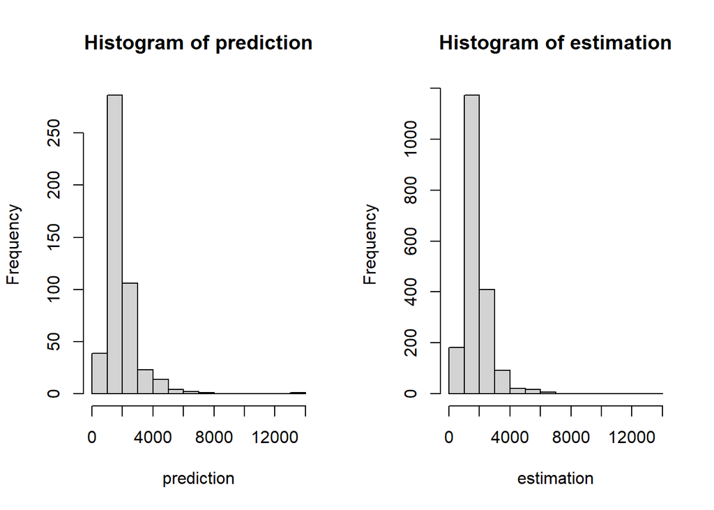

```r
prediction <- predict.glm(gamma.log_1, newdata = test, type = "response")
screen(1); hist(prediction)
estimation <- gamma.log_1$fitted.values
screen(2) ; hist(estimation)
```

Nous observons que la prédiction de notre modèle sur l’échantillon test à une tendance similaire à notre estimation sur notre échantillon d’entraînement.

La loi Gamma avec la fonction de lien logarithme est donc un bon potentiel candidat pour notre modèle linéaire généralisé final.

## V) Loi Gaussienne Inverse

### A) Lien 1/mu^2

#### 1) Echantillon sans outliers / sans interactions

```r
invgauss.mu_0 <- glm(ClaimAmount ~ MariStat+Categ+VehUsage+HasKmLimit+ClaimNbResp+ClaimNbNonResp+ClaimNbParking+ClaimNbFireTheft+ClaimNbWindscreen+OutUseNb+RiskArea+BonusMalus+DrivAge_fact, data = train, family = inverse.gaussian(link = "1/mu^2"),start=rep(10e-20,28))
```

```r
mod0_invgauss_mu_1 <- glm(ClaimAmount ~ 1, data = train, family = inverse.gaussian(link = "1/mu^2"))
AIC(mod0_invgauss_mu_1)
```

```
## [1] 31969.76
```

#### 2) Echantillon sans outliers / avec interactions

Verifions s’il est possible de trouver des interactions de variables tel que le modèle converge.

```r
invgauss.mu_1<- glm(ClaimAmount ~ MariStat+Categ+VehUsage+HasKmLimit+ClaimNbResp+ClaimNbNonResp+ClaimNbParking+ClaimNbFireTheft+ClaimNbWindscreen+OutUseNb+RiskArea+BonusMalus+DrivAge_fact+DrivAge_fact*RiskArea,data = train, family = Gamma(link = "1/mu^2"),start=rep(10e-20,52))
#verification sur la convergence du modèle
invgauss.mu_1$converged
```

```
## [1] FALSE
```

Le modèle ne converge toujours pas. Vérifions s’il est possible de le rendre convergeant à l’aide des méthodes d’outliers.

```r
invgauss.mu_Tukey <- glm(ClaimAmount ~ MariStat+Categ+VehUsage+HasKmLimit+ClaimNbResp+ClaimNbNonResp+ClaimNbParking+ClaimNbFireTheft+ClaimNbWindscreen+OutUseNb+RiskArea+BonusMalus+DrivAge_fact, data = train_Tukey, family = inverse.gaussian(link = "1/mu^2"),start=rep(10e-20,28))
#"Est-ce que l'algorime converge ? "
invgauss.mu_Tukey$converged
```

```
## [1] FALSE
```

### B) Lien Identité, inverse et log

#### 1) Echantillon sans outliers / sans interactions

```r
invgauss.id <- glm(ClaimAmount ~ MariStat+Categ+VehUsage+HasKmLimit+ClaimNbResp+ClaimNbNonResp+ClaimNbParking+ClaimNbFireTheft+ClaimNbWindscreen+OutUseNb+RiskArea+BonusMalus+DrivAge_fact, data = train, family = inverse.gaussian(link = "identity"),na.action = na.exclude)
```

```
## Error in glm.fit(x = structure(c(1, 1, 1, 1, 1, 1, 1, 1, 1, 1, 1, 1, 1, : NA/NaN/Inf dans 'x'
```

```r
#(na.action = na.exclude) permet d'effectuer le GLM sans prendre compte des possibles données manquantes de notre échantillon train
```

```r
invgauss.inv <- glm(ClaimAmount ~ MariStat+Categ+VehUsage+HasKmLimit+ClaimNbResp+ClaimNbNonResp+ClaimNbParking+ClaimNbFireTheft+ClaimNbWindscreen+OutUseNb+RiskArea+BonusMalus+DrivAge_fact, data = train, family = inverse.gaussian(link = "inverse"),na.action = na.exclude)
```

```
## Error in glm.fit(x = structure(c(1, 1, 1, 1, 1, 1, 1, 1, 1, 1, 1, 1, 1, : NA/NaN/Inf dans 'x'
```

Ce message d’erreur apparait suite à la présence de données avec des valeurs Inf, manquantes, indéfinies ou non numériques mais aussi lorsque les variables ne sont pas appropriées pour la regression logistique de notre modèle. Or nous n’avons pas de valeurs manquantes exceptées pour la variable “RecordBeg” d’après le code suivant :

```r
dataSansRecordBeg <- train[, -4]
if (sum(is.na(dataSansRecordBeg)) > 0) {
  NaMiss <- 1
  #présence d'au moins une valeur manquante
} else {
  NaMiss <- 0
  #abscence de valeurs manquantes
}
print(NaMiss)
```

```
## [1] 0
```

Voyons pour le lien “log”

```r
invgauss.log <- glm(ClaimAmount ~ MariStat+Categ+VehUsage+HasKmLimit+ClaimNbResp+ClaimNbNonResp+ClaimNbParking+ClaimNbFireTheft+ClaimNbWindscreen+OutUseNb+RiskArea+BonusMalus+DrivAge_fact, data = train, family = inverse.gaussian(link = "log"))
```

```
## Error: boucle interne 1 ; impossible de corriger le pas
```

Apparaît alors un message comme “Error: boucle interne 1 ; impossible de corriger le pas”

Essayons de voir s’il est possible d’obtenir des GLM à l’aide des méthodes des outliers.

#### 2)Echantillon avec outliers

```r
invgauss.id_Tukey <- glm(ClaimAmount ~ MariStat+Categ+VehUsage+HasKmLimit+ClaimNbResp+ClaimNbNonResp+ClaimNbParking+ClaimNbFireTheft+ClaimNbWindscreen+OutUseNb+RiskArea+BonusMalus+DrivAge_fact, data = train_Hampel_Tukey, family = inverse.gaussian(link = "identity"),na.action = na.exclude)
```

```
## Error in glm.fit(x = structure(c(1, 1, 1, 1, 1, 1, 1, 1, 1, 1, 1, 1, 1, : NA/NaN/Inf dans 'x'
```

```r
invgauss.log_Tukey <- glm(ClaimAmount ~ MariStat+Categ+VehUsage+HasKmLimit+ClaimNbResp+ClaimNbNonResp+ClaimNbParking+ClaimNbFireTheft+ClaimNbWindscreen+OutUseNb+RiskArea+BonusMalus+DrivAge_fact, data = train_Hampel_Tukey, family = inverse.gaussian(link = "log"),na.action = na.exclude)
```

```
## Error: boucle interne 1 ; impossible de corriger le pas
```

Le lien “identité” et “log” renvoient le même message d’erreur pour chaque méthode des outliers et ne sont pas appropriés pour une regression logistique de la loi inverse gaussienne.

```r
invgauss.inv_Tukey <- glm(ClaimAmount ~ MariStat+Categ+VehUsage+HasKmLimit+ClaimNbResp+ClaimNbNonResp+ClaimNbParking+ClaimNbFireTheft+ClaimNbWindscreen+OutUseNb+RiskArea+BonusMalus+DrivAge_fact, data = train_Tukey, family = inverse.gaussian(link = "inverse"))
summary(invgauss.inv_Tukey)
```

```
##
## Call:
## glm(formula = ClaimAmount ~ MariStat + Categ + VehUsage + HasKmLimit +
##     ClaimNbResp + ClaimNbNonResp + ClaimNbParking + ClaimNbFireTheft +
##     ClaimNbWindscreen + OutUseNb + RiskArea + BonusMalus + DrivAge_fact,
##     family = inverse.gaussian(link = "inverse"), data = train_Tukey)
##
## Coefficients:
##                                  Estimate Std. Error t value Pr(>|t|)
## (Intercept)                     1.488e-03  2.785e-04   5.343 1.04e-07 ***
## MariStatOther                  -1.439e-04  8.126e-05  -1.771 0.076688 .
## CategCateg1                     1.988e-04  1.558e-04   1.276 0.202061
## CategCateg2                     4.845e-05  1.222e-04   0.396 0.691834
## CategCateg3                     1.259e-04  1.608e-04   0.783 0.433867
## CategCateg4                     3.938e-05  1.287e-04   0.306 0.759676
## VehUsagePrivate+trip to office  2.351e-04  7.664e-05   3.068 0.002190 **
## VehUsageProfessional            1.030e-04  9.361e-05   1.100 0.271528
## VehUsageProfessional run        1.342e-05  1.313e-04   0.102 0.918579
## HasKmLimit1                    -1.902e-04  9.851e-05  -1.931 0.053607 .
## ClaimNbResp                    -4.562e-05  4.404e-05  -1.036 0.300449
## ClaimNbNonResp                 -9.146e-05  3.137e-05  -2.915 0.003602 **
## ClaimNbParking                 -8.490e-05  6.492e-05  -1.308 0.191145
## ClaimNbFireTheft               -6.801e-05  6.766e-05  -1.005 0.314991
## ClaimNbWindscreen               1.161e-04  3.444e-05   3.370 0.000769 ***
## OutUseNb                       -4.545e-05  3.187e-05  -1.426 0.154032
## RiskAreaZoneRisque2            -1.657e-04  1.342e-04  -1.234 0.217199
## RiskAreaZoneRisque3            -2.561e-04  1.368e-04  -1.872 0.061425 .
## RiskAreaZoneRisque4             1.051e-04  1.816e-04   0.579 0.562798
## BonusMalus                     -3.421e-06  1.960e-06  -1.745 0.081134 .
## DrivAge_fact(25,30]            -2.654e-04  1.535e-04  -1.729 0.083970 .
## DrivAge_fact(30,35]            -5.710e-05  1.611e-04  -0.354 0.723154
## DrivAge_fact(35,40]            -5.043e-05  1.632e-04  -0.309 0.757386
## DrivAge_fact(40,45]            -1.656e-04  1.642e-04  -1.009 0.313221
## DrivAge_fact(45,50]            -2.512e-04  1.629e-04  -1.542 0.123277
## DrivAge_fact(50,58]            -2.979e-04  1.608e-04  -1.852 0.064189 .
## DrivAge_fact(58,65]            -1.743e-04  1.672e-04  -1.042 0.297375
## DrivAge_fact(65,120]           -2.254e-05  1.860e-04  -0.121 0.903583
## ---
## Signif. codes:  0 '***' 0.001 '**' 0.01 '*' 0.05 '.' 0.1 ' ' 1
##
## (Dispersion parameter for inverse.gaussian family taken to be 0.0009821793)
##
##     Null deviance: 4.2856  on 1733  degrees of freedom
## Residual deviance: 4.1967  on 1706  degrees of freedom
## AIC: 27846
##
## Number of Fisher Scoring iterations: 2
```

#### a) Comparaison entre Modèle plein et vide

```r
#Modèle réduit à l'intercept
mod0_invgauss_inv_Tukey_1 <- glm(ClaimAmount ~ 1, data = train_Tukey, family = inverse.gaussian(link = "inverse"))
AIC(mod0_invgauss_inv_Tukey_1)
```

```
## [1] 27828.47
```

```r
#modèle avec la méthode "forward"
modBoth_invgauss_inv_Tukey_1 = step(invgauss.inv_Tukey, mod0_invgauss_inv_Tukey_1, trace=F,direction = c('both'))
AIC(modBoth_invgauss_inv_Tukey_1)
```

```
## [1] 27833.44
```

## VI) Loi Log Normale

### A) Lien identité

#### 1) Echantillon sans outliers

```r
lognorm.id_0 <- glm(log(ClaimAmount) ~ MariStat+Categ+VehUsage+HasKmLimit+ClaimNbResp+ClaimNbNonResp+ClaimNbParking+ClaimNbFireTheft+ClaimNbWindscreen+OutUseNb+RiskArea+BonusMalus+DrivAge_fact, data = train, family = gaussian(link = "identity"))
summary(lognorm.id_0)
```

```
##
## Call:
## glm(formula = log(ClaimAmount) ~ MariStat + Categ + VehUsage +
##     HasKmLimit + ClaimNbResp + ClaimNbNonResp + ClaimNbParking +
##     ClaimNbFireTheft + ClaimNbWindscreen + OutUseNb + RiskArea +
##     BonusMalus + DrivAge_fact, family = gaussian(link = "identity"),
##     data = train)
##
## Coefficients:
##                                 Estimate Std. Error t value Pr(>|t|)
## (Intercept)                     6.286207   0.358816  17.519  < 2e-16 ***
## MariStatOther                  -0.045910   0.099698  -0.460  0.64521
## CategCateg1                    -0.307158   0.207410  -1.481  0.13879
## CategCateg2                    -0.043464   0.165388  -0.263  0.79273
## CategCateg3                    -0.323761   0.218684  -1.480  0.13891
## CategCateg4                    -0.085698   0.178920  -0.479  0.63201
## VehUsagePrivate+trip to office -0.308468   0.108350  -2.847  0.00446 **
## VehUsageProfessional           -0.065891   0.130958  -0.503  0.61492
## VehUsageProfessional run        0.021427   0.186690   0.115  0.90864
## HasKmLimit1                     0.178637   0.140259   1.274  0.20296
## ClaimNbResp                     0.132202   0.059477   2.223  0.02635 *
## ClaimNbNonResp                  0.152831   0.047109   3.244  0.00120 **
## ClaimNbParking                  0.140190   0.089522   1.566  0.11752
## ClaimNbFireTheft                0.171595   0.093603   1.833  0.06693 .
## ClaimNbWindscreen              -0.105697   0.041737  -2.532  0.01141 *
## OutUseNb                        0.027957   0.045772   0.611  0.54141
## RiskAreaZoneRisque2             0.165201   0.164217   1.006  0.31455
## RiskAreaZoneRisque3             0.355008   0.168411   2.108  0.03516 *
## RiskAreaZoneRisque4            -0.013213   0.213217  -0.062  0.95059
## BonusMalus                      0.004864   0.002604   1.868  0.06192 .
## DrivAge_fact(25,30]             0.216534   0.190072   1.139  0.25476
## DrivAge_fact(30,35]            -0.215443   0.195974  -1.099  0.27176
## DrivAge_fact(35,40]            -0.221651   0.200625  -1.105  0.26939
## DrivAge_fact(40,45]             0.022963   0.202480   0.113  0.90972
## DrivAge_fact(45,50]            -0.023609   0.204638  -0.115  0.90817
## DrivAge_fact(50,58]             0.157154   0.199646   0.787  0.43129
## DrivAge_fact(58,65]             0.066427   0.210162   0.316  0.75198
## DrivAge_fact(65,120]            0.298281   0.233945   1.275  0.20246
## ---
## Signif. codes:  0 '***' 0.001 '**' 0.01 '*' 0.05 '.' 0.1 ' ' 1
##
## (Dispersion parameter for gaussian family taken to be 1.752012)
##
##     Null deviance: 3484.7  on 1903  degrees of freedom
## Residual deviance: 3286.8  on 1876  degrees of freedom
## AIC: 6500.8
##
## Number of Fisher Scoring iterations: 2
```

Essayons de reduire l’AIC avec l’aide de nouvelles interactions

```r
lognorm.id_1 <- glm(log(ClaimAmount) ~ MariStat+Categ+VehUsage+HasKmLimit+ClaimNbResp+ClaimNbNonResp+ClaimNbParking+ClaimNbFireTheft+ClaimNbWindscreen+OutUseNb+RiskArea+BonusMalus+DrivAge_fact+HasKmLimit*ClaimNbNonResp+ClaimNbNonResp*VehUsage, data = train, family = gaussian(link = "identity"))
summary(lognorm.id_1)
```

```
##
## Call:
## glm(formula = log(ClaimAmount) ~ MariStat + Categ + VehUsage +
##     HasKmLimit + ClaimNbResp + ClaimNbNonResp + ClaimNbParking +
##     ClaimNbFireTheft + ClaimNbWindscreen + OutUseNb + RiskArea +
##     BonusMalus + DrivAge_fact + HasKmLimit * ClaimNbNonResp +
##     ClaimNbNonResp * VehUsage, family = gaussian(link = "identity"),
##     data = train)
##
## Coefficients:
##                                                Estimate Std. Error t value
## (Intercept)                                    6.128354   0.361366  16.959
## MariStatOther                                 -0.035543   0.099620  -0.357
## CategCateg1                                   -0.301887   0.207227  -1.457
## CategCateg2                                   -0.023590   0.165286  -0.143
## CategCateg3                                   -0.253207   0.219105  -1.156
## CategCateg4                                   -0.075187   0.179467  -0.419
## VehUsagePrivate+trip to office                -0.144545   0.121505  -1.190
## VehUsageProfessional                           0.113256   0.145885   0.776
## VehUsageProfessional run                       0.077442   0.219920   0.352
## HasKmLimit1                                    0.371612   0.157955   2.353
## ClaimNbResp                                    0.138404   0.059452   2.328
## ClaimNbNonResp                                 0.409163   0.099178   4.126
## ClaimNbParking                                 0.152901   0.089439   1.710
## ClaimNbFireTheft                               0.173266   0.093496   1.853
## ClaimNbWindscreen                             -0.111836   0.041703  -2.682
## OutUseNb                                       0.026225   0.045704   0.574
## RiskAreaZoneRisque2                            0.174651   0.163933   1.065
## RiskAreaZoneRisque3                            0.362365   0.168166   2.155
## RiskAreaZoneRisque4                            0.001419   0.212795   0.007
## BonusMalus                                     0.004688   0.002599   1.804
## DrivAge_fact(25,30]                            0.210492   0.189670   1.110
## DrivAge_fact(30,35]                           -0.211174   0.195644  -1.079
## DrivAge_fact(35,40]                           -0.219744   0.200223  -1.097
## DrivAge_fact(40,45]                            0.005086   0.202067   0.025
## DrivAge_fact(45,50]                           -0.029262   0.204242  -0.143
## DrivAge_fact(50,58]                            0.154415   0.199210   0.775
## DrivAge_fact(58,65]                            0.057919   0.209766   0.276
## DrivAge_fact(65,120]                           0.303575   0.233534   1.300
## HasKmLimit1:ClaimNbNonResp                    -0.771312   0.327192  -2.357
```

[output cut: 31 more lines]

```
## DrivAge_fact(65,120]                           0.19379
## HasKmLimit1:ClaimNbNonResp                     0.01851 *
## VehUsagePrivate+trip to office:ClaimNbNonResp  0.00687 **
## VehUsageProfessional:ClaimNbNonResp            0.01104 *
## VehUsageProfessional run:ClaimNbNonResp        0.57935
## ---
## Signif. codes:  0 '***' 0.001 '**' 0.01 '*' 0.05 '.' 0.1 ' ' 1
##
## (Dispersion parameter for gaussian family taken to be 1.743477)
##
##     Null deviance: 3484.7  on 1903  degrees of freedom
## Residual deviance: 3263.8  on 1872  degrees of freedom
## AIC: 6495.4
##
## Number of Fisher Scoring iterations: 2
```

Comparons les avec le modèle réduit à l’intercept

```r
mod0_lognorm_id_0 <- glm(log(ClaimAmount) ~ 1, data = train, family = gaussian(link = "identity"))
AIC(mod0_lognorm_id_0)
```

```
## [1] 6558.158
```

Regardons le modèle réduit par la méthode Both

```r
modBoth_lognorm_id_1 = step(lognorm.id_1, mod0_lognorm_id_0, trace=F,direction = c('both'))
summary(modBoth_lognorm_id_1)
```

```
##
## Call:
## glm(formula = log(ClaimAmount) ~ VehUsage + HasKmLimit + ClaimNbResp +
##     ClaimNbNonResp + ClaimNbParking + ClaimNbFireTheft + ClaimNbWindscreen +
##     RiskArea + BonusMalus + DrivAge_fact + HasKmLimit:ClaimNbNonResp +
##     VehUsage:ClaimNbNonResp, family = gaussian(link = "identity"),
##     data = train)
##
## Coefficients:
##                                                Estimate Std. Error t value
## (Intercept)                                    6.004322   0.319814  18.774
## VehUsagePrivate+trip to office                -0.053534   0.106044  -0.505
## VehUsageProfessional                           0.131987   0.119638   1.103
## VehUsageProfessional run                       0.135366   0.193671   0.699
## HasKmLimit1                                    0.381628   0.157734   2.419
## ClaimNbResp                                    0.141116   0.059401   2.376
## ClaimNbNonResp                                 0.422599   0.098265   4.301
## ClaimNbParking                                 0.159364   0.089278   1.785
## ClaimNbFireTheft                               0.177109   0.093236   1.900
## ClaimNbWindscreen                             -0.113126   0.041500  -2.726
## RiskAreaZoneRisque2                            0.179045   0.163094   1.098
## RiskAreaZoneRisque3                            0.376562   0.166973   2.255
## RiskAreaZoneRisque4                            0.025847   0.212077   0.122
## BonusMalus                                     0.004931   0.002585   1.908
## DrivAge_fact(25,30]                            0.203373   0.187606   1.084
## DrivAge_fact(30,35]                           -0.244504   0.189937  -1.287
## DrivAge_fact(35,40]                           -0.253414   0.193058  -1.313
## DrivAge_fact(40,45]                           -0.031693   0.194721  -0.163
## DrivAge_fact(45,50]                           -0.059337   0.195567  -0.303
## DrivAge_fact(50,58]                            0.102861   0.189812   0.542
## DrivAge_fact(58,65]                           -0.034840   0.196196  -0.178
## DrivAge_fact(65,120]                           0.132108   0.204861   0.645
## HasKmLimit1:ClaimNbNonResp                    -0.796694   0.326454  -2.440
## VehUsagePrivate+trip to office:ClaimNbNonResp -0.342460   0.119534  -2.865
## VehUsageProfessional:ClaimNbNonResp           -0.347698   0.136747  -2.543
## VehUsageProfessional run:ClaimNbNonResp       -0.110270   0.196703  -0.561
##                                               Pr(>|t|)
## (Intercept)                                    < 2e-16 ***
## VehUsagePrivate+trip to office                 0.61374
## VehUsageProfessional                           0.27007
```

[output cut: 18 more lines]

```
## DrivAge_fact(65,120]                           0.51909
## HasKmLimit1:ClaimNbNonResp                     0.01476 *
## VehUsagePrivate+trip to office:ClaimNbNonResp  0.00422 **
## VehUsageProfessional:ClaimNbNonResp            0.01108 *
## VehUsageProfessional run:ClaimNbNonResp        0.57514
## ---
## Signif. codes:  0 '***' 0.001 '**' 0.01 '*' 0.05 '.' 0.1 ' ' 1
##
## (Dispersion parameter for gaussian family taken to be 1.743379)
##
##     Null deviance: 3484.7  on 1903  degrees of freedom
## Residual deviance: 3274.1  on 1878  degrees of freedom
## AIC: 6489.4
##
## Number of Fisher Scoring iterations: 2
```

#### 2) Echantillon avec études des outliers

##### Méthode Tukey

```r
lognorm.id_Tukey <- glm(log(ClaimAmount) ~ MariStat+Categ+VehUsage+HasKmLimit+ClaimNbResp+ClaimNbNonResp+ClaimNbParking+ClaimNbFireTheft+ClaimNbWindscreen+OutUseNb+RiskArea+BonusMalus+DrivAge_fact+HasKmLimit*ClaimNbNonResp+ClaimNbNonResp*VehUsage, data = train_Tukey, family = gaussian(link = "identity"))

mod0_lognorm_id_Tukey_1 <- glm(log(ClaimAmount) ~ 1, data = train_Tukey, family = gaussian(link = "identity"))
modBoth_lognorm_id_Tukey_1 = step(lognorm.id_Tukey, mod0_lognorm_id_Tukey_1, trace=F,direction = c('both'))

summary(mod0_lognorm_id_Tukey_1)
```

```
##
## Call:
## glm(formula = log(ClaimAmount) ~ 1, family = gaussian(link = "identity"),
##     data = train_Tukey)
##
## Coefficients:
##             Estimate Std. Error t value Pr(>|t|)
## (Intercept)  6.40382    0.02811   227.8   <2e-16 ***
## ---
## Signif. codes:  0 '***' 0.001 '**' 0.01 '*' 0.05 '.' 0.1 ' ' 1
##
## (Dispersion parameter for gaussian family taken to be 1.370006)
##
##     Null deviance: 2374.2  on 1733  degrees of freedom
## Residual deviance: 2374.2  on 1733  degrees of freedom
## AIC: 5469.8
##
## Number of Fisher Scoring iterations: 2
```

```r
summary(lognorm.id_Tukey)
```

```
##
## Call:
## glm(formula = log(ClaimAmount) ~ MariStat + Categ + VehUsage +
##     HasKmLimit + ClaimNbResp + ClaimNbNonResp + ClaimNbParking +
##     ClaimNbFireTheft + ClaimNbWindscreen + OutUseNb + RiskArea +
##     BonusMalus + DrivAge_fact + HasKmLimit * ClaimNbNonResp +
##     ClaimNbNonResp * VehUsage, family = gaussian(link = "identity"),
##     data = train_Tukey)
##
## Coefficients:
##                                                Estimate Std. Error t value
## (Intercept)                                    5.993384   0.335101  17.885
## MariStatOther                                  0.160109   0.093051   1.721
## CategCateg1                                   -0.336215   0.187007  -1.798
## CategCateg2                                   -0.066850   0.149159  -0.448
## CategCateg3                                   -0.148196   0.198955  -0.745
## CategCateg4                                   -0.047282   0.161774  -0.292
## VehUsagePrivate+trip to office                -0.166064   0.111376  -1.491
## VehUsageProfessional                           0.089952   0.132582   0.678
## VehUsageProfessional run                       0.079349   0.196914   0.403
## HasKmLimit1                                    0.291229   0.148750   1.958
## ClaimNbResp                                    0.033691   0.055955   0.602
## ClaimNbNonResp                                 0.339064   0.091650   3.700
## ClaimNbParking                                 0.178204   0.081130   2.197
## ClaimNbFireTheft                               0.146383   0.085211   1.718
## ClaimNbWindscreen                             -0.124726   0.037847  -3.295
## OutUseNb                                       0.064429   0.041350   1.558
## RiskAreaZoneRisque2                            0.120819   0.147165   0.821
## RiskAreaZoneRisque3                            0.249453   0.151477   1.647
## RiskAreaZoneRisque4                           -0.048387   0.191948  -0.252
## BonusMalus                                     0.002471   0.002471   1.000
## DrivAge_fact(25,30]                            0.204187   0.178546   1.144
## DrivAge_fact(30,35]                           -0.045458   0.180951  -0.251
## DrivAge_fact(35,40]                           -0.052869   0.185607  -0.285
## DrivAge_fact(40,45]                            0.030617   0.188109   0.163
## DrivAge_fact(45,50]                            0.050819   0.189147   0.269
## DrivAge_fact(50,58]                            0.158811   0.185548   0.856
## DrivAge_fact(58,65]                            0.054335   0.194151   0.280
## DrivAge_fact(65,120]                           0.098286   0.217521   0.452
## HasKmLimit1:ClaimNbNonResp                    -0.589019   0.296237  -1.988
```

[output cut: 31 more lines]

```
## DrivAge_fact(65,120]                          0.651439
## HasKmLimit1:ClaimNbNonResp                    0.046934 *
## VehUsagePrivate+trip to office:ClaimNbNonResp 0.006444 **
## VehUsageProfessional:ClaimNbNonResp           0.008869 **
## VehUsageProfessional run:ClaimNbNonResp       0.780786
## ---
## Signif. codes:  0 '***' 0.001 '**' 0.01 '*' 0.05 '.' 0.1 ' ' 1
##
## (Dispersion parameter for gaussian family taken to be 1.321127)
##
##     Null deviance: 2374.2  on 1733  degrees of freedom
## Residual deviance: 2248.6  on 1702  degrees of freedom
## AIC: 5437.5
##
## Number of Fisher Scoring iterations: 2
```

```r
summary(modBoth_lognorm_id_Tukey_1)
```

```
##
## Call:
## glm(formula = log(ClaimAmount) ~ MariStat + VehUsage + HasKmLimit +
##     ClaimNbNonResp + ClaimNbParking + ClaimNbFireTheft + ClaimNbWindscreen +
##     OutUseNb + RiskArea + BonusMalus + HasKmLimit:ClaimNbNonResp +
##     VehUsage:ClaimNbNonResp, family = gaussian(link = "identity"),
##     data = train_Tukey)
##
## Coefficients:
##                                                Estimate Std. Error t value
## (Intercept)                                    5.939143   0.212764  27.914
## MariStatOther                                  0.162710   0.087892   1.851
## VehUsagePrivate+trip to office                -0.133589   0.080782  -1.654
## VehUsageProfessional                           0.083821   0.094856   0.884
## VehUsageProfessional run                       0.112638   0.162896   0.691
## HasKmLimit1                                    0.288636   0.148043   1.950
## ClaimNbNonResp                                 0.335947   0.090220   3.724
## ClaimNbParking                                 0.184507   0.080723   2.286
## ClaimNbFireTheft                               0.146763   0.084946   1.728
## ClaimNbWindscreen                             -0.128221   0.037476  -3.421
## OutUseNb                                       0.063439   0.040959   1.549
## RiskAreaZoneRisque2                            0.119296   0.146074   0.817
## RiskAreaZoneRisque3                            0.247856   0.149829   1.654
## RiskAreaZoneRisque4                           -0.032787   0.190775  -0.172
## BonusMalus                                     0.002861   0.001911   1.497
## HasKmLimit1:ClaimNbNonResp                    -0.613231   0.294790  -2.080
## VehUsagePrivate+trip to office:ClaimNbNonResp -0.300702   0.110003  -2.734
## VehUsageProfessional:ClaimNbNonResp           -0.323818   0.124461  -2.602
## VehUsageProfessional run:ClaimNbNonResp       -0.019629   0.174076  -0.113
##                                               Pr(>|t|)
## (Intercept)                                    < 2e-16 ***
## MariStatOther                                 0.064305 .
## VehUsagePrivate+trip to office                0.098372 .
## VehUsageProfessional                          0.376999
## VehUsageProfessional run                      0.489362
## HasKmLimit1                                   0.051377 .
## ClaimNbNonResp                                0.000203 ***
## ClaimNbParking                                0.022394 *
## ClaimNbFireTheft                              0.084220 .
## ClaimNbWindscreen                             0.000638 ***
## OutUseNb                                      0.121602
## RiskAreaZoneRisque2                           0.414224
## RiskAreaZoneRisque3                           0.098258 .
## RiskAreaZoneRisque4                           0.863568
## BonusMalus                                    0.134509
## HasKmLimit1:ClaimNbNonResp                    0.037653 *
## VehUsagePrivate+trip to office:ClaimNbNonResp 0.006330 **
## VehUsageProfessional:ClaimNbNonResp           0.009354 **
## VehUsageProfessional run:ClaimNbNonResp       0.910234
## ---
## Signif. codes:  0 '***' 0.001 '**' 0.01 '*' 0.05 '.' 0.1 ' ' 1
##
## (Dispersion parameter for gaussian family taken to be 1.321311)
##
##     Null deviance: 2374.2  on 1733  degrees of freedom
## Residual deviance: 2266.0  on 1715  degrees of freedom
## AIC: 5424.9
##
## Number of Fisher Scoring iterations: 2
```

### B) Lien inverse

#### 1) Echantillon sans les outliers

Modele Complet :

```r
lognorm.inv_0 <- glm(log(ClaimAmount) ~ MariStat+Categ+VehUsage+HasKmLimit+ClaimNbResp+ClaimNbNonResp+ClaimNbParking+ClaimNbFireTheft+ClaimNbWindscreen+OutUseNb+RiskArea+BonusMalus+DrivAge_fact, data = train, family = gaussian(link = "inverse"))

summary(lognorm.inv_0)
```

```
##
## Call:
## glm(formula = log(ClaimAmount) ~ MariStat + Categ + VehUsage +
##     HasKmLimit + ClaimNbResp + ClaimNbNonResp + ClaimNbParking +
##     ClaimNbFireTheft + ClaimNbWindscreen + OutUseNb + RiskArea +
##     BonusMalus + DrivAge_fact, family = gaussian(link = "inverse"),
##     data = train)
##
## Coefficients:
##                                  Estimate Std. Error t value Pr(>|t|)
## (Intercept)                     1.587e-01  7.965e-03  19.930  < 2e-16 ***
## MariStatOther                   9.651e-04  2.209e-03   0.437 0.662220
## CategCateg1                     7.609e-03  4.738e-03   1.606 0.108487
## CategCateg2                     1.407e-03  3.695e-03   0.381 0.703407
## CategCateg3                     7.226e-03  4.823e-03   1.498 0.134181
## CategCateg4                     2.051e-03  3.938e-03   0.521 0.602593
## VehUsagePrivate+trip to office  6.688e-03  2.314e-03   2.890 0.003894 **
## VehUsageProfessional            1.733e-03  2.832e-03   0.612 0.540643
## VehUsageProfessional run       -4.048e-04  4.068e-03  -0.100 0.920743
## HasKmLimit1                    -3.117e-03  2.998e-03  -1.040 0.298633
## ClaimNbResp                    -2.917e-03  1.273e-03  -2.292 0.022039 *
## ClaimNbNonResp                 -3.386e-03  9.879e-04  -3.428 0.000622 ***
## ClaimNbParking                 -2.712e-03  1.916e-03  -1.415 0.157152
## ClaimNbFireTheft               -3.544e-03  1.972e-03  -1.797 0.072523 .
## ClaimNbWindscreen               2.365e-03  9.982e-04   2.369 0.017918 *
## OutUseNb                       -7.743e-04  9.949e-04  -0.778 0.436501
## RiskAreaZoneRisque2            -3.732e-03  3.936e-03  -0.948 0.343244
## RiskAreaZoneRisque3            -8.149e-03  4.002e-03  -2.036 0.041872 *
## RiskAreaZoneRisque4             4.569e-04  5.168e-03   0.088 0.929570
## BonusMalus                     -1.071e-04  5.547e-05  -1.931 0.053632 .
## DrivAge_fact(25,30]            -5.388e-03  4.105e-03  -1.313 0.189458
## DrivAge_fact(30,35]             4.815e-03  4.444e-03   1.084 0.278656
## DrivAge_fact(35,40]             5.249e-03  4.518e-03   1.162 0.245463
## DrivAge_fact(40,45]            -7.686e-04  4.490e-03  -0.171 0.864096
## DrivAge_fact(45,50]             9.297e-05  4.545e-03   0.020 0.983683
## DrivAge_fact(50,58]            -3.903e-03  4.404e-03  -0.886 0.375559
## DrivAge_fact(58,65]            -1.600e-03  4.627e-03  -0.346 0.729485
## DrivAge_fact(65,120]           -6.969e-03  5.079e-03  -1.372 0.170184
## ---
## Signif. codes:  0 '***' 0.001 '**' 0.01 '*' 0.05 '.' 0.1 ' ' 1
##
## (Dispersion parameter for gaussian family taken to be 1.751648)
##
##     Null deviance: 3484.7  on 1903  degrees of freedom
## Residual deviance: 3286.1  on 1876  degrees of freedom
## AIC: 6500.4
##
## Number of Fisher Scoring iterations: 6
```

Modèle avec des interactions :

```r
lognorm.inv_1 <- glm(log(ClaimAmount) ~ MariStat+Categ+VehUsage+HasKmLimit+ClaimNbResp+ClaimNbNonResp+ClaimNbParking+ClaimNbFireTheft+ClaimNbWindscreen+OutUseNb+RiskArea+BonusMalus+DrivAge_fact+HasKmLimit*ClaimNbNonResp+ClaimNbNonResp*VehUsage, data = train, family = gaussian(link = "inverse"))

summary(lognorm.inv_1)
```

```
##
## Call:
## glm(formula = log(ClaimAmount) ~ MariStat + Categ + VehUsage +
##     HasKmLimit + ClaimNbResp + ClaimNbNonResp + ClaimNbParking +
##     ClaimNbFireTheft + ClaimNbWindscreen + OutUseNb + RiskArea +
##     BonusMalus + DrivAge_fact + HasKmLimit * ClaimNbNonResp +
##     ClaimNbNonResp * VehUsage, family = gaussian(link = "inverse"),
##     data = train)
##
## Coefficients:
##                                                 Estimate Std. Error t value
## (Intercept)                                    1.626e-01  8.052e-03  20.199
## MariStatOther                                  6.117e-04  2.211e-03   0.277
## CategCateg1                                    7.322e-03  4.744e-03   1.543
## CategCateg2                                    7.478e-04  3.704e-03   0.202
## CategCateg3                                    5.369e-03  4.837e-03   1.110
## CategCateg4                                    1.617e-03  3.962e-03   0.408
## VehUsagePrivate+trip to office                 3.184e-03  2.649e-03   1.202
## VehUsageProfessional                          -2.243e-03  3.200e-03  -0.701
## VehUsageProfessional run                      -1.721e-03  4.913e-03  -0.350
## HasKmLimit1                                   -7.149e-03  3.287e-03  -2.175
## ClaimNbResp                                   -3.032e-03  1.268e-03  -2.390
## ClaimNbNonResp                                -8.012e-03  1.937e-03  -4.136
## ClaimNbParking                                -2.889e-03  1.918e-03  -1.506
## ClaimNbFireTheft                              -3.583e-03  1.975e-03  -1.814
## ClaimNbWindscreen                              2.534e-03  9.981e-04   2.538
## OutUseNb                                      -7.675e-04  9.927e-04  -0.773
## RiskAreaZoneRisque2                           -4.163e-03  3.939e-03  -1.057
## RiskAreaZoneRisque3                           -8.465e-03  4.005e-03  -2.113
## RiskAreaZoneRisque4                           -1.206e-04  5.164e-03  -0.023
## BonusMalus                                    -1.028e-04  5.546e-05  -1.854
## DrivAge_fact(25,30]                           -5.113e-03  4.108e-03  -1.245
## DrivAge_fact(30,35]                            4.524e-03  4.442e-03   1.018
## DrivAge_fact(35,40]                            4.949e-03  4.511e-03   1.097
## DrivAge_fact(40,45]                           -3.788e-04  4.488e-03  -0.084
## DrivAge_fact(45,50]                            1.403e-04  4.543e-03   0.031
## DrivAge_fact(50,58]                           -3.859e-03  4.403e-03  -0.876
## DrivAge_fact(58,65]                           -1.450e-03  4.630e-03  -0.313
## DrivAge_fact(65,120]                          -7.059e-03  5.084e-03  -1.388
## HasKmLimit1:ClaimNbNonResp                     1.562e-02  7.534e-03   2.073
```

[output cut: 31 more lines]

```
## DrivAge_fact(65,120]                            0.1652
## HasKmLimit1:ClaimNbNonResp                      0.0383 *
## VehUsagePrivate+trip to office:ClaimNbNonResp   0.0161 *
## VehUsageProfessional:ClaimNbNonResp             0.0170 *
## VehUsageProfessional run:ClaimNbNonResp         0.6017
## ---
## Signif. codes:  0 '***' 0.001 '**' 0.01 '*' 0.05 '.' 0.1 ' ' 1
##
## (Dispersion parameter for gaussian family taken to be 1.745236)
##
##     Null deviance: 3484.7  on 1903  degrees of freedom
## Residual deviance: 3267.1  on 1872  degrees of freedom
## AIC: 6497.4
##
## Number of Fisher Scoring iterations: 6
```

Regardons l’AIC du modèle réduit à l’intercept

```r
mod0_lognorm_inv_0 <- glm(log(ClaimAmount) ~ 1, data = train, family = gaussian(link = "inverse"))
AIC(mod0_lognorm_inv_0)
```

```
## [1] 6558.158
```

```r
modBoth_lognorm_inv_1 = step(lognorm.inv_1, mod0_lognorm_inv_0, trace=F,direction = c('both'))
summary(modBoth_lognorm_id_1)
```

[output not shown]

[output cut: 18 more lines]

```
## DrivAge_fact(65,120]                           0.51909
## HasKmLimit1:ClaimNbNonResp                     0.01476 *
## VehUsagePrivate+trip to office:ClaimNbNonResp  0.00422 **
## VehUsageProfessional:ClaimNbNonResp            0.01108 *
## VehUsageProfessional run:ClaimNbNonResp        0.57514
## ---
## Signif. codes:  0 '***' 0.001 '**' 0.01 '*' 0.05 '.' 0.1 ' ' 1
##
## (Dispersion parameter for gaussian family taken to be 1.743379)
##
##     Null deviance: 3484.7  on 1903  degrees of freedom
## Residual deviance: 3274.1  on 1878  degrees of freedom
## AIC: 6489.4
##
## Number of Fisher Scoring iterations: 2
```

#### 2) Echantillon avec études des outliers

##### Méthode Tukey

```r
lognorm.inv_Tukey <- glm(log(ClaimAmount) ~ MariStat+Categ+VehUsage+HasKmLimit+ClaimNbResp+ClaimNbNonResp+ClaimNbParking+ClaimNbFireTheft+ClaimNbWindscreen+OutUseNb+RiskArea+BonusMalus+DrivAge_fact+HasKmLimit*ClaimNbNonResp+ClaimNbNonResp*VehUsage, data = train_Tukey, family = gaussian(link = "inverse"))

mod0_lognorm_inv_Tukey_1 <- glm(log(ClaimAmount) ~ 1, data = train_Tukey, family = gaussian(link = "inverse"))
modBoth_lognorm_inv_Tukey_1 = step(lognorm.inv_Tukey, mod0_lognorm_inv_Tukey_1, trace=F,direction = c('both'))

summary(mod0_lognorm_inv_Tukey_1)
```

```
##
## Call:
## glm(formula = log(ClaimAmount) ~ 1, family = gaussian(link = "inverse"),
##     data = train_Tukey)
##
## Coefficients:
##              Estimate Std. Error t value Pr(>|t|)
## (Intercept) 0.1561568  0.0006854   227.8   <2e-16 ***
## ---
## Signif. codes:  0 '***' 0.001 '**' 0.01 '*' 0.05 '.' 0.1 ' ' 1
##
## (Dispersion parameter for gaussian family taken to be 1.370006)
##
##     Null deviance: 2374.2  on 1733  degrees of freedom
## Residual deviance: 2374.2  on 1733  degrees of freedom
## AIC: 5469.8
##
## Number of Fisher Scoring iterations: 5
```

```r
summary(lognorm.inv_Tukey)
```

```
##
## Call:
## glm(formula = log(ClaimAmount) ~ MariStat + Categ + VehUsage +
##     HasKmLimit + ClaimNbResp + ClaimNbNonResp + ClaimNbParking +
##     ClaimNbFireTheft + ClaimNbWindscreen + OutUseNb + RiskArea +
##     BonusMalus + DrivAge_fact + HasKmLimit * ClaimNbNonResp +
##     ClaimNbNonResp * VehUsage, family = gaussian(link = "inverse"),
##     data = train_Tukey)
##
## Coefficients:
##                                                 Estimate Std. Error t value
## (Intercept)                                    1.667e-01  8.108e-03  20.566
## MariStatOther                                 -4.204e-03  2.333e-03  -1.802
## CategCateg1                                    8.759e-03  4.556e-03   1.923
## CategCateg2                                    1.532e-03  3.532e-03   0.434
## CategCateg3                                    3.036e-03  4.670e-03   0.650
## CategCateg4                                    8.812e-04  3.757e-03   0.235
## VehUsagePrivate+trip to office                 4.079e-03  2.613e-03   1.561
## VehUsageProfessional                          -2.033e-03  3.110e-03  -0.654
## VehUsageProfessional run                      -1.901e-03  4.604e-03  -0.413
## HasKmLimit1                                   -6.193e-03  3.382e-03  -1.831
## ClaimNbResp                                   -9.217e-04  1.324e-03  -0.696
## ClaimNbNonResp                                -7.230e-03  1.942e-03  -3.723
## ClaimNbParking                                -3.943e-03  1.856e-03  -2.124
## ClaimNbFireTheft                              -3.251e-03  1.967e-03  -1.653
## ClaimNbWindscreen                              3.145e-03  9.747e-04   3.226
## OutUseNb                                      -1.735e-03  9.627e-04  -1.802
## RiskAreaZoneRisque2                           -3.120e-03  3.708e-03  -0.841
## RiskAreaZoneRisque3                           -6.137e-03  3.795e-03  -1.617
## RiskAreaZoneRisque4                            1.020e-03  4.915e-03   0.208
## BonusMalus                                    -6.263e-05  5.885e-05  -1.064
## DrivAge_fact(25,30]                           -4.723e-03  4.350e-03  -1.086
## DrivAge_fact(30,35]                            9.382e-04  4.509e-03   0.208
## DrivAge_fact(35,40]                            1.582e-03  4.583e-03   0.345
## DrivAge_fact(40,45]                           -4.937e-04  4.631e-03  -0.107
## DrivAge_fact(45,50]                           -1.245e-03  4.638e-03  -0.269
## DrivAge_fact(50,58]                           -3.681e-03  4.545e-03  -0.810
## DrivAge_fact(58,65]                           -1.328e-03  4.733e-03  -0.281
## DrivAge_fact(65,120]                          -2.056e-03  5.244e-03  -0.392
## HasKmLimit1:ClaimNbNonResp                     1.264e-02  7.191e-03   1.758
```

[output cut: 31 more lines]

```
## DrivAge_fact(65,120]                          0.695029
## HasKmLimit1:ClaimNbNonResp                    0.078869 .
## VehUsagePrivate+trip to office:ClaimNbNonResp 0.012275 *
## VehUsageProfessional:ClaimNbNonResp           0.010809 *
## VehUsageProfessional run:ClaimNbNonResp       0.815776
## ---
## Signif. codes:  0 '***' 0.001 '**' 0.01 '*' 0.05 '.' 0.1 ' ' 1
##
## (Dispersion parameter for gaussian family taken to be 1.322045)
##
##     Null deviance: 2374.2  on 1733  degrees of freedom
## Residual deviance: 2250.1  on 1702  degrees of freedom
## AIC: 5438.7
##
## Number of Fisher Scoring iterations: 5
```

```r
summary(modBoth_lognorm_inv_Tukey_1)
```

```
##
## Call:
## glm(formula = log(ClaimAmount) ~ MariStat + VehUsage + HasKmLimit +
##     ClaimNbNonResp + ClaimNbParking + ClaimNbFireTheft + ClaimNbWindscreen +
##     OutUseNb + RiskArea + BonusMalus + HasKmLimit:ClaimNbNonResp +
##     VehUsage:ClaimNbNonResp, family = gaussian(link = "inverse"),
##     data = train_Tukey)
##
## Coefficients:
##                                                 Estimate Std. Error t value
## (Intercept)                                    1.679e-01  5.260e-03  31.910
## MariStatOther                                 -4.287e-03  2.208e-03  -1.942
## VehUsagePrivate+trip to office                 3.446e-03  1.975e-03   1.744
## VehUsageProfessional                          -1.608e-03  2.270e-03  -0.708
## VehUsageProfessional run                      -2.306e-03  3.847e-03  -0.599
## HasKmLimit1                                   -6.234e-03  3.362e-03  -1.854
## ClaimNbNonResp                                -7.280e-03  1.912e-03  -3.808
## ClaimNbParking                                -4.069e-03  1.849e-03  -2.201
## ClaimNbFireTheft                              -3.190e-03  1.963e-03  -1.625
## ClaimNbWindscreen                              3.168e-03  9.646e-04   3.284
## OutUseNb                                      -1.569e-03  9.586e-04  -1.636
## RiskAreaZoneRisque2                           -3.020e-03  3.683e-03  -0.820
## RiskAreaZoneRisque3                           -6.011e-03  3.756e-03  -1.600
## RiskAreaZoneRisque4                            8.038e-04  4.892e-03   0.164
## BonusMalus                                    -7.409e-05  4.523e-05  -1.638
## HasKmLimit1:ClaimNbNonResp                     1.332e-02  7.160e-03   1.860
## VehUsagePrivate+trip to office:ClaimNbNonResp  6.481e-03  2.478e-03   2.615
## VehUsageProfessional:ClaimNbNonResp            6.983e-03  2.746e-03   2.543
## VehUsageProfessional run:ClaimNbNonResp        1.528e-04  3.633e-03   0.042
##                                               Pr(>|t|)
## (Intercept)                                    < 2e-16 ***
## MariStatOther                                 0.052358 .
## VehUsagePrivate+trip to office                0.081278 .
## VehUsageProfessional                          0.478789
## VehUsageProfessional run                      0.548938
## HasKmLimit1                                   0.063840 .
## ClaimNbNonResp                                0.000145 ***
## ClaimNbParking                                0.027856 *
## ClaimNbFireTheft                              0.104263
## ClaimNbWindscreen                             0.001043 **
## OutUseNb                                      0.101957
## RiskAreaZoneRisque2                           0.412327
## RiskAreaZoneRisque3                           0.109692
## RiskAreaZoneRisque4                           0.869525
## BonusMalus                                    0.101596
## HasKmLimit1:ClaimNbNonResp                    0.063081 .
## VehUsagePrivate+trip to office:ClaimNbNonResp 0.008997 **
## VehUsageProfessional:ClaimNbNonResp           0.011093 *
## VehUsageProfessional run:ClaimNbNonResp       0.966460
## ---
## Signif. codes:  0 '***' 0.001 '**' 0.01 '*' 0.05 '.' 0.1 ' ' 1
##
## (Dispersion parameter for gaussian family taken to be 1.32259)
##
##     Null deviance: 2374.2  on 1733  degrees of freedom
## Residual deviance: 2268.2  on 1715  degrees of freedom
## AIC: 5426.6
##
## Number of Fisher Scoring iterations: 5
```

### C) Lien log

#### 1)Echantillon sans outliers

```r
lognorm.log_0 <- glm(log(ClaimAmount) ~ MariStat+Categ+VehUsage+HasKmLimit+ClaimNbResp+ClaimNbNonResp+ClaimNbParking+ClaimNbFireTheft+ClaimNbWindscreen+OutUseNb+RiskArea+BonusMalus+DrivAge_fact, data = train, family = gaussian(link = "log"))

summary(lognorm.log_0)
```

```
##
## Call:
## glm(formula = log(ClaimAmount) ~ MariStat + Categ + VehUsage +
##     HasKmLimit + ClaimNbResp + ClaimNbNonResp + ClaimNbParking +
##     ClaimNbFireTheft + ClaimNbWindscreen + OutUseNb + RiskArea +
##     BonusMalus + DrivAge_fact, family = gaussian(link = "log"),
##     data = train)
##
## Coefficients:
##                                  Estimate Std. Error t value Pr(>|t|)
## (Intercept)                     1.8390312  0.0535401  34.349  < 2e-16 ***
## MariStatOther                  -0.0066991  0.0148793  -0.450 0.652600
## CategCateg1                    -0.0484445  0.0313746  -1.544 0.122741
## CategCateg2                    -0.0079062  0.0247779  -0.319 0.749701
## CategCateg3                    -0.0486055  0.0325452  -1.493 0.135481
## CategCateg4                    -0.0132694  0.0266105  -0.499 0.618083
## VehUsagePrivate+trip to office -0.0456461  0.0158508  -2.880 0.004025 **
## VehUsageProfessional           -0.0107864  0.0192738  -0.560 0.575792
## VehUsageProfessional run        0.0029077  0.0275882   0.105 0.916072
## HasKmLimit1                     0.0238475  0.0205045   1.163 0.244963
## ClaimNbResp                     0.0197645  0.0087156   2.268 0.023460 *
## ClaimNbNonResp                  0.0228277  0.0068443   3.335 0.000869 ***
## ClaimNbParking                  0.0195608  0.0131103   1.492 0.135864
## ClaimNbFireTheft                0.0246748  0.0136030   1.814 0.069849 .
## ClaimNbWindscreen              -0.0158237  0.0064749  -2.444 0.014622 *
## OutUseNb                        0.0046799  0.0067767   0.691 0.489911
## RiskAreaZoneRisque2             0.0249679  0.0254733   0.980 0.327134
## RiskAreaZoneRisque3             0.0539432  0.0260043   2.074 0.038179 *
## RiskAreaZoneRisque4            -0.0024618  0.0332608  -0.074 0.941007
## BonusMalus                      0.0007268  0.0003812   1.907 0.056693 .
## DrivAge_fact(25,30]             0.0342347  0.0279450   1.225 0.220701
## DrivAge_fact(30,35]            -0.0321940  0.0295036  -1.091 0.275330
## DrivAge_fact(35,40]            -0.0341872  0.0300993  -1.136 0.256180
## DrivAge_fact(40,45]             0.0043136  0.0301647   0.143 0.886304
## DrivAge_fact(45,50]            -0.0020673  0.0305189  -0.068 0.946002
## DrivAge_fact(50,58]             0.0248938  0.0296662   0.839 0.401505
## DrivAge_fact(58,65]             0.0104485  0.0312032   0.335 0.737772
## DrivAge_fact(65,120]            0.0458429  0.0345330   1.328 0.184502
## ---
## Signif. codes:  0 '***' 0.001 '**' 0.01 '*' 0.05 '.' 0.1 ' ' 1
##
## (Dispersion parameter for gaussian family taken to be 1.751756)
##
##     Null deviance: 3484.7  on 1903  degrees of freedom
## Residual deviance: 3286.3  on 1876  degrees of freedom
## AIC: 6500.5
##
## Number of Fisher Scoring iterations: 5
```

```r
lognorm.log_1 <- glm(log(ClaimAmount) ~ MariStat+Categ+VehUsage+HasKmLimit+ClaimNbResp+ClaimNbNonResp+ClaimNbParking+ClaimNbFireTheft+ClaimNbWindscreen+OutUseNb+RiskArea+BonusMalus+DrivAge_fact+ClaimNbNonResp*HasKmLimit+ClaimNbNonResp*VehUsage, data = train, family = gaussian(link = "log"))

summary(lognorm.log_1)
```

```
##
## Call:
## glm(formula = log(ClaimAmount) ~ MariStat + Categ + VehUsage +
##     HasKmLimit + ClaimNbResp + ClaimNbNonResp + ClaimNbParking +
##     ClaimNbFireTheft + ClaimNbWindscreen + OutUseNb + RiskArea +
##     BonusMalus + DrivAge_fact + ClaimNbNonResp * HasKmLimit +
##     ClaimNbNonResp * VehUsage, family = gaussian(link = "log"),
##     data = train)
##
## Coefficients:
##                                                 Estimate Std. Error t value
## (Intercept)                                    1.8138266  0.0540106  33.583
## MariStatOther                                 -0.0048003  0.0148783  -0.323
## CategCateg1                                   -0.0470249  0.0313751  -1.499
## CategCateg2                                   -0.0041362  0.0247939  -0.167
## CategCateg3                                   -0.0370826  0.0326261  -1.137
## CategCateg4                                   -0.0110268  0.0267237  -0.413
## VehUsagePrivate+trip to office                -0.0214561  0.0179581  -1.195
## VehUsageProfessional                           0.0160945  0.0216262   0.744
## VehUsageProfessional run                       0.0117402  0.0329030   0.357
## HasKmLimit1                                    0.0519194  0.0227733   2.280
## ClaimNbResp                                    0.0206435  0.0087015   2.372
## ClaimNbNonResp                                 0.0577460  0.0138890   4.158
## ClaimNbParking                                 0.0211467  0.0131102   1.613
## ClaimNbFireTheft                               0.0249925  0.0136043   1.837
## ClaimNbWindscreen                             -0.0168698  0.0064733  -2.606
## OutUseNb                                       0.0045219  0.0067654   0.668
## RiskAreaZoneRisque2                            0.0271696  0.0254536   1.067
## RiskAreaZoneRisque3                            0.0556129  0.0259888   2.140
## RiskAreaZoneRisque4                            0.0006429  0.0332096   0.019
## BonusMalus                                     0.0006994  0.0003807   1.837
## DrivAge_fact(25,30]                            0.0329908  0.0279143   1.182
## DrivAge_fact(30,35]                           -0.0308449  0.0294720  -1.047
## DrivAge_fact(35,40]                           -0.0329133  0.0300411  -1.096
## DrivAge_fact(40,45]                            0.0017748  0.0301209   0.059
## DrivAge_fact(45,50]                           -0.0024959  0.0304734  -0.082
## DrivAge_fact(50,58]                            0.0246587  0.0296250   0.832
## DrivAge_fact(58,65]                            0.0093775  0.0311791   0.301
## DrivAge_fact(65,120]                           0.0467546  0.0345169   1.355
## HasKmLimit1:ClaimNbNonResp                    -0.1104751  0.0497347  -2.221
```

[output cut: 31 more lines]

```
## DrivAge_fact(65,120]                           0.17573
## HasKmLimit1:ClaimNbNonResp                     0.02645 *
## VehUsagePrivate+trip to office:ClaimNbNonResp  0.00981 **
## VehUsageProfessional:ClaimNbNonResp            0.01301 *
## VehUsageProfessional run:ClaimNbNonResp        0.57969
## ---
## Signif. codes:  0 '***' 0.001 '**' 0.01 '*' 0.05 '.' 0.1 ' ' 1
##
## (Dispersion parameter for gaussian family taken to be 1.744188)
##
##     Null deviance: 3484.7  on 1903  degrees of freedom
## Residual deviance: 3265.1  on 1872  degrees of freedom
## AIC: 6496.2
##
## Number of Fisher Scoring iterations: 5
```

Modèle réduit à l’intercept :

```r
mod0_lognorm_log_0 <- glm(log(ClaimAmount) ~ 1, data = train, family = gaussian(link = "log"))
AIC(mod0_lognorm_log_0)
```

```
## [1] 6558.158
```

```r
modBoth_lognorm_log_1 = step(lognorm.log_1, mod0_lognorm_log_0, trace=F,direction = c('both'))
summary(modBoth_lognorm_log_1)
```

```
##
## Call:
## glm(formula = log(ClaimAmount) ~ VehUsage + HasKmLimit + ClaimNbResp +
##     ClaimNbNonResp + ClaimNbParking + ClaimNbFireTheft + ClaimNbWindscreen +
##     RiskArea + BonusMalus + DrivAge_fact + HasKmLimit:ClaimNbNonResp +
##     VehUsage:ClaimNbNonResp, family = gaussian(link = "log"),
##     data = train)
##
## Coefficients:
##                                                 Estimate Std. Error t value
## (Intercept)                                    1.7954963  0.0478118  37.553
## VehUsagePrivate+trip to office                -0.0085042  0.0159158  -0.534
## VehUsageProfessional                           0.0184382  0.0178910   1.031
## VehUsageProfessional run                       0.0197509  0.0291366   0.678
## HasKmLimit1                                    0.0539465  0.0227289   2.373
## ClaimNbResp                                    0.0210345  0.0086948   2.419
## ClaimNbNonResp                                 0.0596902  0.0137437   4.343
## ClaimNbParking                                 0.0223670  0.0130903   1.709
## ClaimNbFireTheft                               0.0253944  0.0135706   1.871
## ClaimNbWindscreen                             -0.0168570  0.0064367  -2.619
## RiskAreaZoneRisque2                            0.0280156  0.0253283   1.106
## RiskAreaZoneRisque3                            0.0580278  0.0258100   2.248
## RiskAreaZoneRisque4                            0.0048400  0.0330935   0.146
## BonusMalus                                     0.0007363  0.0003783   1.946
## DrivAge_fact(25,30]                            0.0319768  0.0275895   1.159
## DrivAge_fact(30,35]                           -0.0356901  0.0286402  -1.246
## DrivAge_fact(35,40]                           -0.0379453  0.0289776  -1.309
## DrivAge_fact(40,45]                           -0.0035834  0.0290175  -0.123
## DrivAge_fact(45,50]                           -0.0072092  0.0291626  -0.247
## DrivAge_fact(50,58]                            0.0170188  0.0281986   0.604
## DrivAge_fact(58,65]                           -0.0039126  0.0291616  -0.134
## DrivAge_fact(65,120]                           0.0217185  0.0302350   0.718
## HasKmLimit1:ClaimNbNonResp                    -0.1150353  0.0496210  -2.318
## VehUsagePrivate+trip to office:ClaimNbNonResp -0.0471677  0.0171289  -2.754
## VehUsageProfessional:ClaimNbNonResp           -0.0482733  0.0195600  -2.468
## VehUsageProfessional run:ClaimNbNonResp       -0.0152384  0.0276524  -0.551
##                                               Pr(>|t|)
## (Intercept)                                    < 2e-16 ***
## VehUsagePrivate+trip to office                 0.59318
## VehUsageProfessional                           0.30287
```

[output cut: 18 more lines]

```
## DrivAge_fact(65,120]                           0.47265
## HasKmLimit1:ClaimNbNonResp                     0.02054 *
## VehUsagePrivate+trip to office:ClaimNbNonResp  0.00595 **
## VehUsageProfessional:ClaimNbNonResp            0.01368 *
## VehUsageProfessional run:ClaimNbNonResp        0.58165
## ---
## Signif. codes:  0 '***' 0.001 '**' 0.01 '*' 0.05 '.' 0.1 ' ' 1
##
## (Dispersion parameter for gaussian family taken to be 1.744184)
##
##     Null deviance: 3484.7  on 1903  degrees of freedom
## Residual deviance: 3275.6  on 1878  degrees of freedom
## AIC: 6490.3
##
## Number of Fisher Scoring iterations: 4
```

#### 2) Echantillon avec études des outliers

##### Méthode Tukey

```r
lognorm.log_Tukey <- glm(log(ClaimAmount) ~ MariStat+Categ+VehUsage+HasKmLimit+ClaimNbResp+ClaimNbNonResp+ClaimNbParking+ClaimNbFireTheft+ClaimNbWindscreen+OutUseNb+RiskArea+BonusMalus+DrivAge_fact+HasKmLimit*ClaimNbNonResp+ClaimNbNonResp*VehUsage, data = train_Tukey, family = gaussian(link = "log"))

mod0_lognorm_log_Tukey_1 <- glm(log(ClaimAmount) ~ 1, data = train_Tukey, family = gaussian(link = "log"))
modBoth_lognorm_log_Tukey_1 = step(lognorm.log_Tukey, mod0_lognorm_log_Tukey_1, trace=F,direction = c('both'))


summary(lognorm.log_Tukey)
```

```
##
## Call:
## glm(formula = log(ClaimAmount) ~ MariStat + Categ + VehUsage +
##     HasKmLimit + ClaimNbResp + ClaimNbNonResp + ClaimNbParking +
##     ClaimNbFireTheft + ClaimNbWindscreen + OutUseNb + RiskArea +
##     BonusMalus + DrivAge_fact + HasKmLimit * ClaimNbNonResp +
##     ClaimNbNonResp * VehUsage, family = gaussian(link = "log"),
##     data = train_Tukey)
##
## Coefficients:
##                                                 Estimate Std. Error t value
## (Intercept)                                    1.7908604  0.0521765  34.323
## MariStatOther                                  0.0260157  0.0147548   1.763
## CategCateg1                                   -0.0542539  0.0291807  -1.859
## CategCateg2                                   -0.0101455  0.0229799  -0.441
## CategCateg3                                   -0.0214232  0.0305229  -0.702
## CategCateg4                                   -0.0065351  0.0246910  -0.265
## VehUsagePrivate+trip to office                -0.0260660  0.0170700  -1.527
## VehUsageProfessional                           0.0134980  0.0203228   0.664
## VehUsageProfessional run                       0.0122181  0.0301401   0.405
## HasKmLimit1                                    0.0426291  0.0224197   1.901
## ClaimNbResp                                    0.0056160  0.0086233   0.651
## ClaimNbNonResp                                 0.0496753  0.0133650   3.717
## ClaimNbParking                                 0.0265263  0.0122765   2.161
## ClaimNbFireTheft                               0.0217764  0.0129494   1.682
## ClaimNbWindscreen                             -0.0198185  0.0060882  -3.255
## OutUseNb                                       0.0106001  0.0063260   1.676
## RiskAreaZoneRisque2                            0.0194651  0.0233830   0.832
## RiskAreaZoneRisque3                            0.0391608  0.0239975   1.632
## RiskAreaZoneRisque4                           -0.0070548  0.0307582  -0.229
## BonusMalus                                     0.0003948  0.0003820   1.033
## DrivAge_fact(25,30]                            0.0311635  0.0278925   1.117
## DrivAge_fact(30,35]                           -0.0066297  0.0285984  -0.232
## DrivAge_fact(35,40]                           -0.0092531  0.0291896  -0.317
## DrivAge_fact(40,45]                            0.0039171  0.0295433   0.133
## DrivAge_fact(45,50]                            0.0079207  0.0296525   0.267
## DrivAge_fact(50,58]                            0.0241402  0.0290682   0.830
## DrivAge_fact(58,65]                            0.0084985  0.0303488   0.280
## DrivAge_fact(65,120]                           0.0142429  0.0338175   0.421
## HasKmLimit1:ClaimNbNonResp                    -0.0866278  0.0462577  -1.873
```

[output cut: 31 more lines]

```
## DrivAge_fact(65,120]                          0.673685
## HasKmLimit1:ClaimNbNonResp                    0.061278 .
## VehUsagePrivate+trip to office:ClaimNbNonResp 0.008674 **
## VehUsageProfessional:ClaimNbNonResp           0.009676 **
## VehUsageProfessional run:ClaimNbNonResp       0.796183
## ---
## Signif. codes:  0 '***' 0.001 '**' 0.01 '*' 0.05 '.' 0.1 ' ' 1
##
## (Dispersion parameter for gaussian family taken to be 1.321578)
##
##     Null deviance: 2374.2  on 1733  degrees of freedom
## Residual deviance: 2249.3  on 1702  degrees of freedom
## AIC: 5438.1
##
## Number of Fisher Scoring iterations: 4
```

```r
summary(mod0_lognorm_log_Tukey_1)
```

```
##
## Call:
## glm(formula = log(ClaimAmount) ~ 1, family = gaussian(link = "log"),
##     data = train_Tukey)
##
## Coefficients:
##             Estimate Std. Error t value Pr(>|t|)
## (Intercept) 1.856895   0.004389     423   <2e-16 ***
## ---
## Signif. codes:  0 '***' 0.001 '**' 0.01 '*' 0.05 '.' 0.1 ' ' 1
##
## (Dispersion parameter for gaussian family taken to be 1.370008)
##
##     Null deviance: 2374.2  on 1733  degrees of freedom
## Residual deviance: 2374.2  on 1733  degrees of freedom
## AIC: 5469.8
##
## Number of Fisher Scoring iterations: 4
```

```r
summary(modBoth_lognorm_log_Tukey_1)
```

```
##
## Call:
## glm(formula = log(ClaimAmount) ~ MariStat + VehUsage + HasKmLimit +
##     ClaimNbNonResp + ClaimNbParking + ClaimNbFireTheft + ClaimNbWindscreen +
##     OutUseNb + RiskArea + BonusMalus + HasKmLimit:ClaimNbNonResp +
##     VehUsage:ClaimNbNonResp, family = gaussian(link = "log"),
##     data = train_Tukey)
##
## Coefficients:
##                                                 Estimate Std. Error t value
## (Intercept)                                    1.7828788  0.0334908  53.235
## MariStatOther                                  0.0264764  0.0139429   1.899
## VehUsagePrivate+trip to office                -0.0214554  0.0126488  -1.696
## VehUsageProfessional                           0.0117147  0.0146885   0.798
## VehUsageProfessional run                       0.0161967  0.0250483   0.647
## HasKmLimit1                                    0.0425758  0.0222989   1.909
## ClaimNbNonResp                                 0.0495764  0.0131594   3.767
## ClaimNbParking                                 0.0274455  0.0122185   2.246
## ClaimNbFireTheft                               0.0216756  0.0129127   1.679
## ClaimNbWindscreen                             -0.0201986  0.0060269  -3.351
## OutUseNb                                       0.0100057  0.0062751   1.595
## RiskAreaZoneRisque2                            0.0190444  0.0232130   0.820
## RiskAreaZoneRisque3                            0.0386496  0.0237402   1.628
## RiskAreaZoneRisque4                           -0.0051110  0.0305819  -0.167
## BonusMalus                                     0.0004628  0.0002945   1.571
## HasKmLimit1:ClaimNbNonResp                    -0.0906374  0.0460312  -1.969
## VehUsagePrivate+trip to office:ClaimNbNonResp -0.0442682  0.0165088  -2.681
## VehUsageProfessional:ClaimNbNonResp           -0.0476747  0.0185085  -2.576
## VehUsageProfessional run:ClaimNbNonResp       -0.0019786  0.0251830  -0.079
##                                               Pr(>|t|)
## (Intercept)                                    < 2e-16 ***
## MariStatOther                                 0.057743 .
## VehUsagePrivate+trip to office                0.090021 .
## VehUsageProfessional                          0.425246
## VehUsageProfessional run                      0.517966
## HasKmLimit1                                   0.056388 .
## ClaimNbNonResp                                0.000171 ***
## ClaimNbParking                                0.024816 *
## ClaimNbFireTheft                              0.093408 .
## ClaimNbWindscreen                             0.000822 ***
## OutUseNb                                      0.111005
## RiskAreaZoneRisque2                           0.412089
## RiskAreaZoneRisque3                           0.103704
## RiskAreaZoneRisque4                           0.867292
## BonusMalus                                    0.116334
## HasKmLimit1:ClaimNbNonResp                    0.049109 *
## VehUsagePrivate+trip to office:ClaimNbNonResp 0.007400 **
## VehUsageProfessional:ClaimNbNonResp           0.010083 *
## VehUsageProfessional run:ClaimNbNonResp       0.937385
## ---
## Signif. codes:  0 '***' 0.001 '**' 0.01 '*' 0.05 '.' 0.1 ' ' 1
##
## (Dispersion parameter for gaussian family taken to be 1.321921)
##
##     Null deviance: 2374.2  on 1733  degrees of freedom
## Residual deviance: 2267.1  on 1715  degrees of freedom
## AIC: 5425.7
##
## Number of Fisher Scoring iterations: 4
```

### D) Comparaison entre les modèles

Les modèles linéaires généralisés de la loi Log Normale converge. Leur critère d’AIC beaucoup plus faible que ceux des autres modèles et de nombreuses variables significatives dont la p-valeur est inférieure à 0.05 sont présentent dans les modèles. Regardons lequel des différents liens est le meilleur pour estimer la loi en comparant leur estimation et prédiction.

```r
split.screen(1:2)
```

```
## [1] 3 4
```

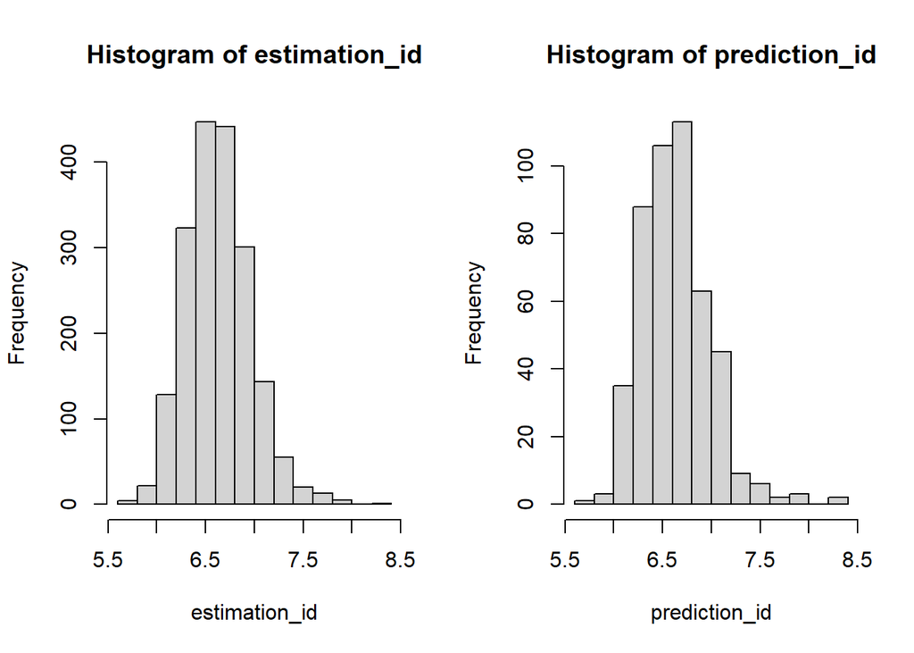

```r
estimation_id <- modBoth_lognorm_id_1$fitted.values
screen(1) ; hist(estimation_id)

prediction_id <- predict.glm(modBoth_lognorm_id_1, newdata = test, type = "response")
screen(2) ; hist(prediction_id)
```

```r
split.screen(1:2)
```

```
## [1] 5 6
```

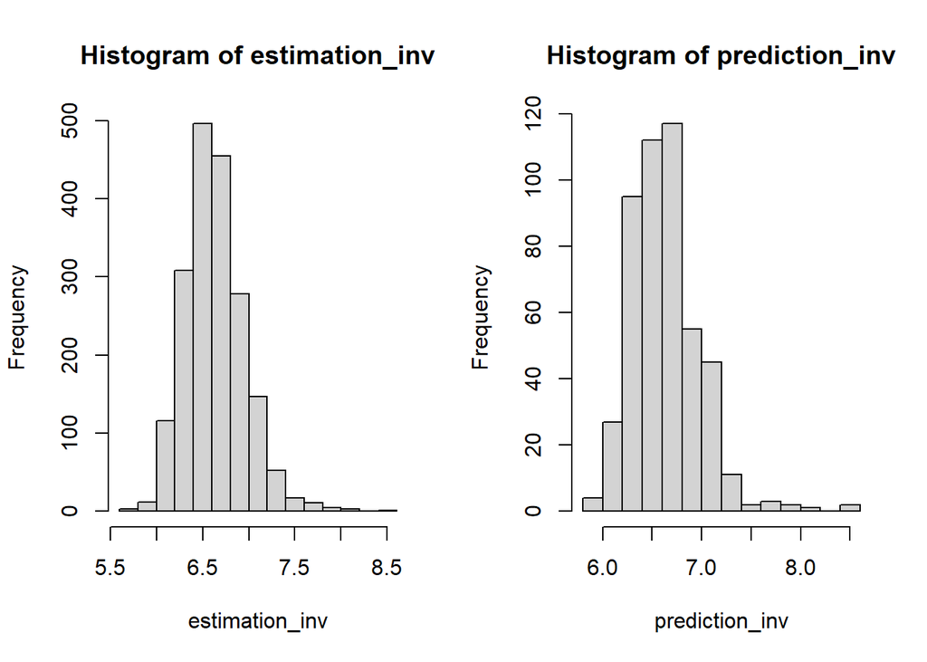

```r
estimation_inv <- modBoth_lognorm_inv_1$fitted.values
screen(1) ; hist(estimation_inv)

prediction_inv <- predict.glm(modBoth_lognorm_inv_1, newdata = test, type = "response")
screen(2) ; hist(prediction_inv)
```

```r
split.screen(1:2)
```

```
## [1] 7 8
```

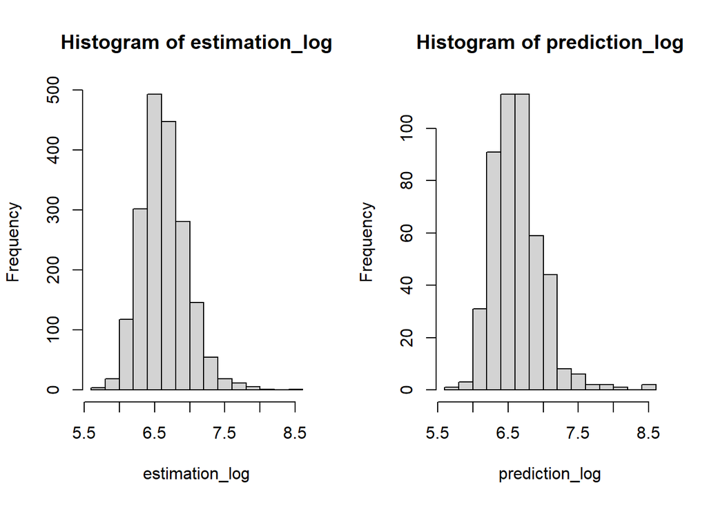

```r
estimation_log <- modBoth_lognorm_log_1$fitted.values
screen(1) ; hist(estimation_log)

prediction_log <- predict.glm(modBoth_lognorm_log_1, newdata = test, type = "response")
screen(2) ; hist(prediction_log)
```

# VII) Quelques critères

## Deviance

### Loi Gamma

Pour la fonction de lien “inverse” :

```r
#Avec méthode de Tukey et avec intéractions
  #modèle réduit à l'intercept
round(deviance(mod0_gamma_inv_Tukey))
```

```
## [1] 1959
```

```r
  #modèle plein
round(deviance(gamma.inv_Tukey))
```

```
## [1] 1865
```

```r
  #modèle both
round(deviance(modBoth_gamma_inv_Tukey))
```

```
## [1] 1873
```

Pour la fonction de lien “log” :

```r
#Sans outlier, avec intéractions
  #modèle réduit à l'intercept
round(deviance(mod0_gamma_log_1))
```

```
## [1] 3287
```

```r
  #modèle plein
round(deviance(gamma.log_1))
```

```
## [1] 2917
```

```r
  #modèle both
round(deviance(modBoth_gamma_log_1))
```

```
## [1] 2927
```

```r
#Avec méthode de Tukey et avec intéractions
  #modèle réduit à l'intercept
round(deviance(mod0_gamma_log_Tukey))
```

```
## [1] 1959
```

```r
  #modèle plein
round(deviance(gamma.log_Tukey))
```

```
## [1] 1815
```

```r
  #modèle both
round(deviance(modBoth_gamma_log_Tukey))
```

```
## [1] 1860
```

Pour la fonction de lien “identité” :

```r
#Avec méthode de Tukey et avec intéractions
  #modèle réduit à l'intercept
round(deviance(mod0_gamma_id_Tukey))
```

```
## [1] 1959
```

```r
  #modèle plein
round(deviance(gamma.id_Tukey))
```

```
## [1] 1857
```

```r
  #modèle both
round(deviance(modBoth_gamma_id_Tukey))
```

```
## [1] 1860
```

### Loi Inverse Gaussienne

Pour la fonction de lien “inverse” :

```r
#Avec méthode de Tukey et avec intéractions
  #modèle réduit à l'intercept
deviance(mod0_invgauss_inv_Tukey_1)
```

```
## [1] 4.285563
```

```r
  #modèle plein
deviance(invgauss.inv_Tukey)
```

```
## [1] 4.196666
```

```r
  #modèle both
deviance(modBoth_invgauss_inv_Tukey_1)
```

```
## [1] 4.204709
```

### Loi Log Normale

Pour la fonction de lien “identité” :

```r
#Sans outlier, avec intéractions
  #modèle réduit à l'intercept
round(deviance(mod0_lognorm_id_0))
```

```
## [1] 3485
```

```r
  #modèle plein
round(deviance(lognorm.id_1))
```

```
## [1] 3264
```

```r
  #modèle both
round(deviance(modBoth_lognorm_id_1))
```

```
## [1] 3274
```

```r
#Avec méthode de Tukey et avec intéractions
  #modèle réduit à l'intercept
round(deviance(mod0_lognorm_id_Tukey_1))
```

```
## [1] 2374
```

```r
  #modèle plein
round(deviance(lognorm.id_Tukey))
```

```
## [1] 2249
```

```r
  #modèle both
round(deviance(modBoth_lognorm_id_Tukey_1))
```

```
## [1] 2266
```

Pour la fonction de lien “inverse” :

```r
#Sans outlier, avec intéractions
  #modèle réduit à l'intercept
round(deviance(mod0_lognorm_inv_0))
```

```
## [1] 3485
```

```r
  #modèle plein
round(deviance(lognorm.inv_1))
```

```
## [1] 3267
```

```r
  #modèle both
round(deviance(modBoth_lognorm_inv_1))
```

```
## [1] 3278
```

```r
#Avec méthode de Tukey et avec intéractions
  #modèle réduit à l'intercept
round(deviance(mod0_lognorm_inv_Tukey_1))
```

```
## [1] 2374
```

```r
  #modèle plein
round(deviance(lognorm.inv_Tukey))
```

```
## [1] 2250
```

```r
  #modèle both
round(deviance(modBoth_lognorm_inv_Tukey_1))
```

```
## [1] 2268
```

Pour la fonction de lien “log” :

```r
#Sans outlier, avec intéractions
  #modèle réduit à l'intercept
round(deviance(mod0_lognorm_log_0))
```

```
## [1] 3485
```

```r
  #modèle plein
round(deviance(lognorm.log_1))
```

```
## [1] 3265
```

```r
  #modèle both
round(deviance(modBoth_lognorm_log_1))
```

```
## [1] 3276
```

```r
#Avec méthode de Tukey et avec intéractions
  #modèle réduit à l'intercept
round(deviance(mod0_lognorm_log_Tukey_1))
```

```
## [1] 2374
```

```r
  #modèle plein
round(deviance(lognorm.log_Tukey))
```

```
## [1] 2249
```

```r
  #modèle both
round(deviance(modBoth_lognorm_log_Tukey_1))
```

```
## [1] 2267
```

## -2*log(L)

### Loi Gamma

Pour la fonction de lien “inverse” :

```r
#Avec méthode de Tukey et avec intéractions
  #modèle réduit à l'intercept
round(-2*as.numeric(logLik(mod0_gamma_inv_Tukey)))
```

```
## [1] 27657
```

```r
  #modèle plein
round(-2*as.numeric(logLik(gamma.inv_Tukey)))
```

```
## [1] 27557
```

```r
  #modèle both
round(-2*as.numeric(logLik(modBoth_gamma_inv_Tukey)))
```

```
## [1] 27565
```

Pour la fonction de lien “log” :

```r
#Sans outlier, avec intéractions
  #modèle réduit à l'intercept
round(-2*as.numeric(logLik(mod0_gamma_log_1)))
```

```
## [1] 32235
```

```r
  #modèle plein
round(-2*as.numeric(logLik(gamma.log_1)))
```

```
## [1] 31955
```

```r
  #modèle both
round(-2*as.numeric(logLik(modBoth_gamma_log_1)))
```

```
## [1] 31963
```

```r
#Avec méthode de Tukey et avec intéractions
  #modèle réduit à l'intercept
round(-2*as.numeric(logLik(mod0_gamma_log_Tukey)))
```

```
## [1] 27657
```

```r
  #modèle plein
round(-2*as.numeric(logLik(gamma.log_Tukey)))
```

```
## [1] 27503
```

```r
  #modèle both
round(-2*as.numeric(logLik(modBoth_gamma_log_Tukey)))
```

```
## [1] 27552
```

Pour la fonction de lien “identité” :

```r
#Avec méthode de Tukey et avec intéractions
  #modèle réduit à l'intercept
round(-2*as.numeric(logLik(mod0_gamma_id_Tukey)))
```

```
## [1] 27657
```

```r
  #modèle plein
round(-2*as.numeric(logLik(gamma.id_Tukey)))
```

```
## [1] 27548
```

```r
  #modèle both
round(-2*as.numeric(logLik(modBoth_gamma_id_Tukey)))
```

```
## [1] 27552
```

### Loi Inverse Gaussienne

Pour la fonction de lien “inverse” :

```r
#Avec méthode de Tukey et avec intéractions
  #modèle réduit à l'intercept
round(-2*as.numeric(logLik(mod0_invgauss_inv_Tukey_1)))
```

```
## [1] 27824
```

```r
  #modèle plein
round(-2*as.numeric(logLik(invgauss.inv_Tukey)))
```

```
## [1] 27788
```

```r
  #modèle both
round(-2*as.numeric(logLik(modBoth_invgauss_inv_Tukey_1)))
```

```
## [1] 27791
```

### Loi Log Normale

Pour la fonction de lien “identité” :

```r
#Sans outlier, avec intéractions
  #modèle réduit à l'intercept
round(-2*as.numeric(logLik(mod0_lognorm_id_0)))
```

```
## [1] 6554
```

```r
  #modèle plein
round(-2*as.numeric(logLik(lognorm.id_1)))
```

```
## [1] 6429
```

```r
  #modèle both
round(-2*as.numeric(logLik(modBoth_lognorm_id_1)))
```

```
## [1] 6435
```

```r
#Avec méthode de Tukey et avec intéractions
  #modèle réduit à l'intercept
round(-2*as.numeric(logLik(mod0_lognorm_id_Tukey_1)))
```

```
## [1] 5466
```

```r
  #modèle plein
round(-2*as.numeric(logLik(lognorm.id_Tukey)))
```

```
## [1] 5371
```

```r
  #modèle both
round(-2*as.numeric(logLik(modBoth_lognorm_id_Tukey_1)))
```

```
## [1] 5385
```

Pour la fonction de lien “inverse” :

```r
#Sans outlier, avec intéractions
  #modèle réduit à l'intercept
round(-2*as.numeric(logLik(mod0_lognorm_inv_0)))
```

```
## [1] 6554
```

```r
  #modèle plein
round(-2*as.numeric(logLik(lognorm.inv_1)))
```

```
## [1] 6431
```

```r
  #modèle both
round(-2*as.numeric(logLik(modBoth_lognorm_inv_1)))
```

```
## [1] 6438
```

```r
#Avec méthode de Tukey et avec intéractions
  #modèle réduit à l'intercept
round(-2*as.numeric(logLik(mod0_lognorm_inv_Tukey_1)))
```

```
## [1] 5466
```

```r
  #modèle plein
round(-2*as.numeric(logLik(lognorm.inv_Tukey)))
```

```
## [1] 5373
```

```r
  #modèle both
round(-2*as.numeric(logLik(modBoth_lognorm_inv_Tukey_1)))
```

```
## [1] 5387
```

Pour la fonction de lien “log” :

```r
#Sans outlier, avec intéractions
  #modèle réduit à l'intercept
round(-2*as.numeric(logLik(mod0_lognorm_log_0)))
```

```
## [1] 6554
```

```r
  #modèle plein
round(-2*as.numeric(logLik(lognorm.log_1)))
```

```
## [1] 6430
```

```r
  #modèle both
round(-2*as.numeric(logLik(modBoth_lognorm_log_1)))
```

```
## [1] 6436
```

```r
#Avec méthode de Tukey et avec intéractions
  #modèle réduit à l'intercept
round(-2*as.numeric(logLik(mod0_lognorm_log_Tukey_1)))
```

```
## [1] 5466
```

```r
  #modèle plein
round(-2*as.numeric(logLik(lognorm.log_Tukey)))
```

```
## [1] 5372
```

```r
  #modèle both
round(-2*as.numeric(logLik(modBoth_lognorm_log_Tukey_1)))
```

```
## [1] 5386
```

Les résultats sont disponibles dans la table 5.2 de notre mémoire. On constate que le modèle plein de la loi Gamma assoviée au lien logarithme apporte une meilleure différence avec le modèle vide que ce soit pour les critères d’AIC, de deviance ou de LogLikelihood. Puis, il y a le modèle plein de la loi Log Normale.

# Modèle final

Parmi les modèles réalisés, la loi Gamma avec le lien “log” et la loi Log Normale sont les plus aptes à ajuster la variable “ClaimAmount” de nos données. Celles-ci n’entraînent pas de problème de divergence et proposent de nombreuses variables qui auraient un impact sur notre variable de sévérité.

Les plus variables les plus intéressantes et significatives sont :

- “ClaimNbResp”
- “ClaimNbNonResp”
- “ClaimWindscreen”

Vérifions quand même si les modèles proposés permettent de prédire correctement nos variables sur le jeu de donnée “test”

## Prédiction et Estimation

```r
#Pour le modèle Gamma pour le lien logarithme
split.screen(1:2)
```

```
## [1]  9 10
```

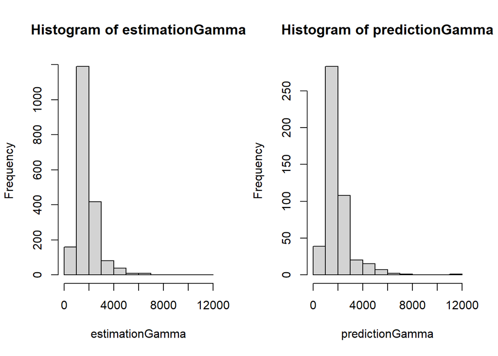

```r
estimationGamma <- modBoth_gamma_log_1$fitted.values
screen(1) ; hist(estimationGamma)

predictionGamma <- predict.glm(modBoth_gamma_log_1, newdata = test, type = "response")
screen(2) ; hist(predictionGamma)
```

On observe bien une tendance très proche entre l’estimation de nos données et la prédiction

```r
# Pour la loi Log Normale au lien identité
split.screen(1:2)
```

```
## [1] 11 12
```

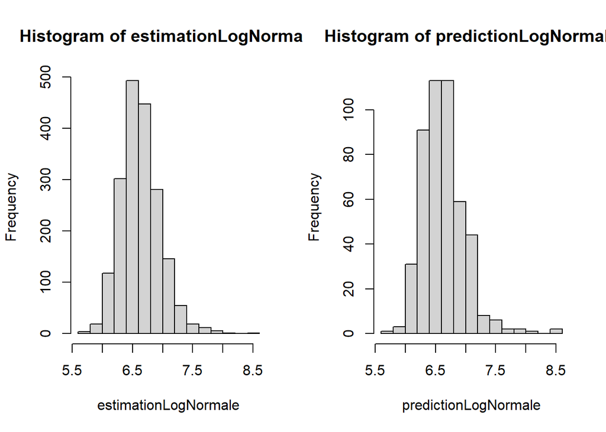

```r
estimationLogNormale <- modBoth_lognorm_log_1$fitted.values
screen(1) ; hist(estimationLogNormale)

predictionLogNormale <- predict.glm(modBoth_lognorm_log_1, newdata = test, type = "response")
screen(2) ; hist(predictionLogNormale)
```

### MSE

```r
#MSE de Gamma
mseGamma <- mean((predictionGamma - test$ClaimAmount)^2)
mseGamma
```

```
## [1] 8553952
```

```r
#MSE de Log Normale
mseLogNormale <- mean((predictionLogNormale - test$ClaimAmount)^2)
mseLogNormale
```

```
## [1] 11714715
```

### RMSE

```r
#RMSE de Gamma
rmseGamma <- sqrt(mseGamma)
rmseGamma
```

```
## [1] 2924.714
```

```r
#RMSE de Gamma
rmseLogNormale <- sqrt(mseLogNormale)
rmseLogNormale
```

```
## [1] 3422.677
```

### MAE

```r
#MSE de Gamma
maeGamma <- mean(abs(predictionGamma - test$ClaimAmount))
maeGamma
```

```
## [1] 1776.998
```

```r
#MSE de Gamma
maeLogNormale <- mean(abs(predictionLogNormale - test$ClaimAmount))
maeLogNormale
```

```
## [1] 1875.082
```